# Kostenoffenlegung als Wettbewerbsvorteil

Chancen und Potenziale der Kostentransparenz

# Motivation

Die Untersuchung von Kostentransparenz ist aus ökonomischer Sicht besonders spannend, da sie Einblicke in das Zusammenspiel von Marktverhalten, Preiswahrnehmung und Konsumentenvertrauen ermöglicht. In klassischen Märkten gilt Information als asymmetrisch verteilt - insbesondere Kostenstrukturen bleiben für Konsument:innen meist verborgen. Wenn Unternehmen jedoch freiwillig ihre Produktionskosten offenlegen, entsteht eine neue Form der Marktkommunikation, die sowohl auf das Kaufverhalten als auch auf die Markenbindung Einfluss nehmen kann.

In diesem Projekt beschäftigen Sie sich mit der ökonomischen Wirkung unterschiedlicher Formen von Kostentransparenz, darunter produktbezogene Einzelkosten-Offenlegung im Point-of-Sale oder auch verbal vermittelte Transparenz in Kombination mit Vertrauensmessung. Ziel ist es, zu untersuchen, wie sich diese Varianten auf Zahlungsbereitschaft, Vertrauen und wahrgenommene Preisfairness auswirken.

Kern dieser Ausarbeitung ist die Frage, inwiefern Kostentransparenz eine rationale Kaufentscheidung unterstützt oder über emotionale Mechanismen - etwa durch erhöhte Markenattraktivität - wirkt. Für die Analyse greifen Sie auf ein breites Methodenrepertoire zurück, das ökonomische Modellierung mit experimenteller Verhaltensforschung verbindet, und leisten so einen Beitrag zum besseren Verständnis moderner Konsumentenentscheidungen in transparenten Märkten. Für ihre Analyse verwenden Sie die Daten der folgenden Ausarbeitung:

**Mohan, B., Buell, R. W., & John, L. K. (2020). Lifting the veil: The benefits of cost transparency. Marketing Science, 39(6), 1105-1121.**

# Aufbau der Studie

1. Lesen Sie sich den folgenden Text zum Hintergrund und Aufbau der Studie durch und beantworten Sie nachfolgende Fragen dazu:

Der Ausgangspunkt der betrachteten Untersuchung war ein reales Ereignis: Ein Online-Händler stellte im Dezember 2013 ein hochwertiges Lederportemonnaie zum Verkauf. Einige Wochen später wurde auf den Produktseiten eine Infografik zur Kostenzusammensetzung ergänzt, allerdings versehentlich nur bei drei von fünf Farbvarianten. Obwohl der Händler diesen Fehler nicht beabsichtigte, entstand daraus ein sogenanntes natürliches Experiment, also eine reale Vergleichssituation mit kontrollierbaren Unterschieden. Die Verkäufe konnten analysiert werden, um zu überprüfen, ob die Offenlegung der Produktionskosten einen Einfluss auf das Kaufverhalten hatte.

Dieses natürliche Experiment lieferte erste Hinweise darauf, dass Kostentransparenz wirkt - und war damit die Basis für zwei gezielte Experimente im Labor, die Sie sich in diesem Projekt genauer anschauen sollen. Beide Laborexperimente knüpfen an die reale Ausgangslage an - gehen aber unterschiedliche Forschungsfragen an:

Experiment 1: In einem realitätsnahen Online-Setting wurde untersucht, ob Konsument:innen anders entscheiden, wenn sie Informationen zu Produktionskosten sehen. Hierbei sahen die Teilnehmer:innen eine Produktseite für einen Rucksack von Everlane - entweder mit oder ohne Kostenaufstellung (vgl. Abbildung 1: Kostentransparenz Infografik im Anhang). Zusätzlich wurde ein Vergleichsprodukt von J. Crew gezeigt (ohne Hinweise zur Kostenzusammensetzung). Die Teilnehmer:innen mussten entscheiden, von welchem Anbieter sie lieber einen Gutschein erhalten würden. Das Ziel der Forscher war es zu messen, ob Konsument:innen bei mehr Transparenz auch eher kaufen, folglich sich für diesen Gutschein entscheiden.

Experiment 2: Nachdem Experiment 1 zeigte, dass es einen Effekt der Kostentransparenz gibt, stellt sich die psychologische Anschlussfrage, warum es diesen Effekt gibt und wie dieser festzumachen ist. So sahen die Teilnehmer:innen im 2. Experiment ein fiktives Produkt - eine Schokoladentafel. In der Kontrollgruppe wurden nur übliche Produktinfos gezeigt. In der Treatmentgruppe gab es zusätzlich eine detaillierte Kostenaufstellung (vgl. Abbildung 2: Design der Schokoladenverpackung ohne und mit Kostentransparenz im Anhang). Im Anschluss wurden Vertrauen in die Marke und Kaufbereitschaft durch einen Fragebogen abgefragt. So sollte herausgefunden werden, ob Vertrauen der zentrale psychologische Mechanismus für die Kaufentscheidung der Kund:innen ist.

Beantworten Sie nun folgende Fragen:

1. Welches reale Ereignis war der Auslöser der Forschung?
2. Welche konkrete Verhaltensfrage steht im Mittelpunkt von Experiment 1 - Was wollten die Forscher:innen direkt am Kaufverhalten testen?
3. Welcher psychologische Faktor steht im Zentrum von Experiment 2 - und wie hängt er mit dem Kaufverhalten zusammen?

Hier bitte ihre **Antwort** eintragen. a) Der Auslöser war ein reales Ereignis, bei dem ein Online-Händler im Dezember 2013 ein hochwertiges Lederportemonnaie zum Verkauf anbot. Einige Wochen später wurde versehentlich auf den Produktseiten nur bei drei von fünf Farbvarianten eine Infografik zur Kostenzusammensetzung ergänzt. Dieser Fehler führte zu einem natürlichen Experiment, das analysiert wurde, um zu prüfen, ob die Offenlegung der Produktionskosten das Kaufverhalten beeinflusst.

2. Im ersten Experiment wurde untersucht, ob Konsument:innen anders entscheiden, wenn sie Informationen zu Produktionskosten sehen. Konkret wollten die Forscher:innen testen, ob mehr Kostentransparenz dazu führt, dass sich Konsument:innen eher für den Kauf (bzw. hier für den Gutschein) des Produkts mit Kostentransparenz entscheiden.
3. Im zweiten Experiment stand das Vertrauen in die Marke im Zentrum. Die Forscher:innen wollten herausfinden, ob die Offenlegung der Produktionskosten das Vertrauen in die Marke erhöht und ob dieses Vertrauen der zentrale psychologische Mechanismus ist, der die Kaufbereitschaft und damit das Kaufverhalten beeinflusst.

Nachdem Sie nun die grundlegende Forschungsidee und Zielsetzung der beiden Experimente kennengelernt haben, befassen wir uns im nächsten Schritt vertiefend mit Experiment 1. Ziel ist es, den genauen Aufbau, sowie das konkrete Verhalten der Teilnehmer:innen besser zu verstehen.

2. Lesen Sie sich den folgenden Text zum Aufbau des ersten Experiments durch und beantworten Sie anschließend Fragen dazu:

Cost transparency refers to the disclosure of the costs to produce a good or provide a service. Although cost transparency is a strategy traditionally employed in the context of supplier-firm relationships, wherein the two-way sharing of cost information between parties facilitates collaboration on cost reduction measures, we investigate its effects within the context of consumer-firm relationships. Information on the costs associated with providing goods and services is rarely shared with consumers, but we provide evidence of when and why voluntarily doing so can increase consumers’ purchase interest. Specifically, building on the psychology of disclosure and trust, we posit that cost transparency, insofar as it represents an act of intimate disclosure, fosters trust. In turn, we propose that this heightened trust increases consumers’ willingness to purchase from the transparent firm. In the sections that follow, we discuss our central predictions and highlight alternative accounts. Then, we present experiments, conducted in the lab and in the field, that document the main effects of cost transparency, its underlying psychological drivers, and conditions that moderate its effects.

This first experiment explores how cost transparency influences consumer preferences in an online shopping context. The study was designed as a between-subjects randomized experiment using an incentive-compatible setup, meaning participants made real choices with the possibility of receiving a tangible reward. A total of 509 U.S.-based participants were recruited through Amazon Mechanical Turk (MTurk). Each participant was randomly assigned to one of two experimental conditions:

- Cost Transparency Condition: Participants were shown a simulated product page for a backpack sold by the retailer Everlane. This page included a cost breakdown infographic, listing the production costs such as materials, labor, transport, and duties, with a clearly stated total cost.
- Control Condition: Participants saw the same backpack from Everlane but without any cost information. In both conditions, participants also saw a comparable backpack from J. Crew, which does not practice cost transparency.

Participants were instructed to view both product pages and then asked which company they would prefer to receive a $50 gift card from. Their response served as the main behavioral outcome, representing a choice between the transparent vs. non-transparent retailer. To ensure accurate interpretation of the presented information, a comprehension check followed the main choice question. Participants were also asked for demographic information such as age, gender, income, and education, to allow for potential control variables in later analysis.

Beantworten Sie nun folgende Fragen:

1. Wie viele Personen nahmen final an dem Experiment teil?
2. Worin bestand der Unterschied zwischen der Transparenzbedingung und der Kontrollbedingung?
3. Welche Anreizstruktur wurde verwendet, um die Entscheidung der Teilnehmenden realistisch zu gestalten?
4. Wie unterschieden sich die beiden gezeigten Onlinehändler im Experiment?
5. Warum wurde im Anschluss an die Entscheidungsfrage ein Verständnischeck durchgeführt?
6. In der Beschreibung des Experiments wird von “between-subjects randomized experiment using an incentive-compatible setup” gesprochen. Was versteht man hierunter im Detail?

*Hinweis:* Für die Beantwortung der letzten Frage können Sie [diesen Artikel (Seite 1-5)](https://www.researchgate.net/publication/268269783_Incentives_in_Experiments_A_Theoretical_Analysis) als Grundlage verwenden.

a)Es wurden 509 US-amerikanische Teilnehmer über Amazon Mechanical Turk rekrutiert und zufällig einer von zwei Versuchsbedingungen zugeteilt.

b)In der Transparenzbedingung wurden den Teilnehmern Produktseiten gezeigt, auf denen eine detaillierte Kostenaufstellung für die Herstellung des Produkts ersichtlich war. Diese beinhaltete Angaben zu Materialkosten, Arbeitskosten, Transportgebühren und Zöllen. Dadurch konnten die Teilnehmer genau nachvollziehen, wie sich der Preis des Produkts zusammensetzt.

c)Damit die Entscheidungen der Teilnehmer möglichst realistisch und bedeutsam waren, wurde das Experiment incentive-compatible gestaltet. Das bedeutet, dass die Teilnehmer nicht nur hypothetische Entscheidungen treffen mussten, sondern tatsächlich die Möglichkeit hatten, eine Belohnung zu erhalten. Konkret sollten sie angeben, von welchem Unternehmen sie lieber einen $50-Geschenkgutschein erhalten würden. Ihre Entscheidung spiegelte somit echte Präferenzen wider, da eine reale Belohnung auf dem Spiel stand und nicht lediglich eine theoretische Befragung stattfand.

d)Im Experiment wurden Produkte von zwei verschiedenen Onlinehändlern gezeigt:

Everlane – Dieses Unternehmen verfolgt eine Strategie der Kostentransparenz. In der Transparenzbedingung wurde den Teilnehmern eine detaillierte Aufschlüsselung der Produktionskosten des Produkts präsentiert.

J.Crew – Dieser Händler praktiziert keine Kostentransparenz. Das bedeutet, dass die Teilnehmer zwar ebenfalls einen vergleichbaren Rucksack sehen konnten, jedoch ohne jegliche Angaben zu den Herstellungskosten.

Durch diesen Vergleich sollte untersucht werden, ob eine Offenlegung der Produktionskosten das Vertrauen der Kunden beeinflusst und ihre Kaufentscheidung positiv beeinflusst.

e)Nach der Frage, für welches Unternehmen sich die Teilnehmer entschieden, wurde ein Verständnischeck durchgeführt. Dieser diente dazu, sicherzustellen, dass die Teilnehmer die präsentierten Informationen korrekt erfasst und interpretiert hatten. Dadurch sollte ausgeschlossen werden, dass falsche oder ungenaue Antworten die Ergebnisse des Experiments verfälschen. Indem geprüft wurde, ob die Teilnehmer die Kostenaufstellungen richtig verstanden hatten, konnte eine höhere Datenqualität gewährleistet werden.

f)Diese Bezeichnung beschreibt die methodische Gestaltung des Experiments:

Between-subjects experiment: Die Teilnehmer wurden in zwei Gruppen aufgeteilt. Jeder Teilnehmer bekam nur eine der beiden Bedingungen zu sehen – entweder die Produktseite mit Kostenaufstellung (Transparenzbedingung) oder die Produktseite ohne Kostenaufstellung (Kontrollbedingung). Dadurch konnte verglichen werden, wie sich diese unterschiedlichen Präsentationen auf die Entscheidungen der Teilnehmer auswirkten.

Randomized: Die Teilnehmer wurden zufällig einer der beiden Gruppen zugewiesen. Dies verhindert, dass systematische Unterschiede zwischen den Gruppen das Ergebnis verzerren.

Incentive-compatible setup: Die Entscheidung der Teilnehmer war nicht nur hypothetisch, sondern mit einer echten Belohnung verknüpft. Sie konnten einen $50-Geschenkgutschein von einem der Unternehmen gewinnen, sodass ihre Entscheidung eine reale Bedeutung hatte und nicht bloß eine unverbindliche Antwort war.

# Daten

## Datenimport und -aufbereitung

Die Daten, die Sie für die nachfolgenden Analysen verwenden, wurden zu Replikationszwecken von den Autoren der Studie zur Verfügung gestellt und können hier heruntergeladen werden:

**Bhavya Mohan, Ryan W. Buell, Leslie K. John (2020) Lifting the Veil: The Benefits of Cost Transparency. Marketing Science 39(6):1105-1121. mksc.2019.1200.sm1.pdf**

Wir haben die Daten für Sie heruntergeladen und im Unterordner mit dem Namen `Daten` bereitgestellt. Für ihre Analyse werden die Dateien `Experiment1.csv` und `Experiment2.csv` genutzt. Für die Zusatzaufgabe ist die Datei `Experiment3.csv` relevant.

3. Lesen Sie den Datensatz `Experiment1.csv` aus dem Unterordner `Daten` in R ein. Nennen Sie den Datensatz in R `daten_exp1`.

Im Datensatz sind unterschiedliche Variablen enthalten. Weiterhin habe wir Ihnen ein Readme mit den Beschreibungen zu den Variablen bereitgestellt. Nutzen Sie dieses und den Text aus Aufgabe 2, um die Variablen zu beschreiben.

```
## 'data.frame':    509 obs. of  8 variables:
##  $ treatment     : int  0 0 0 0 0 0 0 0 0 0 ...
##  $ everlane      : int  1 0 0 0 0 1 0 0 0 1 ...
##  $ passed        : int  0 1 1 1 1 0 1 1 0 0 ...
##  $ email_provided: int  1 1 1 1 0 1 0 1 1 0 ...
##  $ female        : int  1 1 1 1 1 1 0 0 0 0 ...
##  $ age           : int  31 55 54 43 36 45 77 35 49 27 ...
##  $ educ          : int  3 4 5 4 4 4 5 5 3 4 ...
##  $ income        : int  5 11 7 12 5 10 4 11 6 10 ...
```

Experiment 1:

Experimentelle Bedingung (treatment): Diese Variable gibt an, ob die Teilnehmer die kostentransparente Produktseite gesehen haben. Ein Wert von 1 bedeutet, dass sie eine detaillierte Aufschlüsselung der Produktionskosten gesehen haben, während 0 bedeutet, dass sie die reguläre Produktseite ohne Kostentransparenz gesehen haben.

Verhaltensentscheidung (everlane): Hier wird festgehalten, welches Unternehmen der Teilnehmer bevorzugt. Ein Wert von 1 bedeutet, dass der Teilnehmer sich für die Geschenkkarte von Everlane entschieden hat, während 0 angibt, dass die Geschenkkarte von J.Crew gewählt wurde.

Verständnischeck (passed): Diese Variable zeigt, ob ein Teilnehmer die präsentierten Informationen korrekt interpretiert hat. Wer den Test bestanden hat, erhält eine 1, andernfalls eine 0.

Angabe der E-Mail-Adresse (email_provided): Hier wird dokumentiert, ob Teilnehmer ihre E-Mail-Adresse angegeben haben, um die Geschenkkarte zu erhalten. Eine 1 bedeutet, dass eine Adresse hinterlegt wurde, eine 0, dass keine Angabe gemacht wurde.

Demografische Variablen:

Geschlecht (female): Diese Variable erfasst, ob der Teilnehmer weiblich (1) oder männlich (0) ist.

Alter (age): Das Alter der Teilnehmer wurde als offene Antwort erhoben.

Bildungsgrad (educ): Teilnehmer gaben ihren höchsten Bildungsabschluss an, kategorisiert von 1 (einige Schuljahre) bis 5 (postgraduale Ausbildung).

Einkommensniveau (income): Das monatliche Einkommen wurde in verschiedene Kategorien unterteilt, von 1 (kein Einkommen) bis 11 (über 10.000 Dollar). Eine zusätzliche Kategorie (12) ermöglichte die Antwort „Weiß nicht/Bevorzuge keine Antwort.“

Experiment 2:

Das zweite Experiment untersuchte, ob die Offenlegung von Produktionskosten auf einer Verpackung das Vertrauen der Verbraucher und ihre Kaufwahrscheinlichkeit beeinflusst. Hier wurden ähnliche Kategorien von Variablen erfasst:

Experimentelle Bedingung (cost): Analog zu Experiment 1 zeigt diese Variable an, ob die Teilnehmer eine Schokoladenverpackung mit detaillierter Kostenaufstellung gesehen haben (1) oder eine reguläre Verpackung ohne diese Informationen (0).

Vertrauensbewertung (trust): Die Teilnehmer bewerteten, wie vertrauenswürdig sie das Unternehmen einschätzen. Dies erfolgte auf einer 7-Punkte-Skala von 1 („überhaupt nicht vertrauenswürdig“) bis 7 („sehr vertrauenswürdig“).

Kaufwahrscheinlichkeit (wtb): Um die Auswirkungen der Kostentransparenz auf die Kaufentscheidung zu messen, wurde die wahrscheinliche Kaufabsicht auf einer 7-Punkte-Skala erhoben (1 = „überhaupt nicht wahrscheinlich“, 7 = „sehr wahrscheinlich“).

Demografische Variablen (wie in Experiment 1 erhoben):

Geschlecht (female): 1 für weibliche Teilnehmer, 0 für männliche Teilnehmer.

Alter (age): Erfasst das Alter der Teilnehmer als offene Antwort.

Bildungsgrad (educ): Skala von 1 (einige Schuljahre) bis 5 (postgraduale Ausbildung).

Einkommen (income): Die monatlichen Einkommenskategorien sind identisch mit Experiment 1.

## Deskriptive Analyse

Sie sollten sich im ersten Schritt einen Überblick über ihre Daten verschaffen.

4. Auf Basis des Datensatzes `daten_exp1` aus Aufgabe 3 erstellen Sie eine deskriptive Tabelle mit der Anzahl an Beobachtungen, den Mittelwerten, der Standardabweichungen, dem Median, sowie den Minima und Maxima für alle in `daten_exp1` enthaltenen Variablen.

Beschreiben und interpretieren Sie ihre Tabelle. Gehen Sie insbesondere auf die Verteilungen der einzelnen Variablen ein. Was fällt hier besonders auf.

|  | Beobachtungen | Mittelwert | Median | Standardabweichung | Minimum | Maximum |
| --- | --- | --- | --- | --- | --- | --- |
| treatment | 509 | 0.497 | 0 | 0.500 | 0 | 1 |
| everlane | 509 | 0.627 | 1 | 0.484 | 0 | 1 |
| passed | 509 | 0.774 | 1 | 0.419 | 0 | 1 |
| email_provided | 509 | 0.560 | 1 | 0.497 | 0 | 1 |
| female | 509 | 0.485 | 0 | 0.500 | 0 | 1 |
| age | 505 | 37.592 | 35 | 11.743 | 18 | 81 |
| educ | 505 | 3.764 | 4 | 0.837 | 1 | 5 |
| income | 505 | 7.584 | 8 | 2.429 | 1 | 12 |

Die Tabelle gibt einen detaillierten Überblick über die Alters- und Einkommensverteilung der Teilnehmer im Experiment. Insgesamt wurden 509 Beobachtungen erfasst. Das Durchschnittsalter der Teilnehmer beträgt rund 37,6 Jahre, wobei die Altersverteilung eine relativ hohe Streuung aufweist, wie die Standardabweichung von 11,74 zeigt. Der Median liegt bei 35 Jahren, was darauf hinweist, dass die Altersverteilung leicht asymmetrisch ist, da der Mittelwert etwas höher liegt. Der jüngste Teilnehmer ist 18 Jahre alt, während der älteste Teilnehmer 81 Jahre erreicht. Diese breite Altersspanne zeigt, dass sowohl junge Erwachsene als auch ältere Personen in der Studie vertreten sind.

Auffällig ist, dass sowohl das Alter als auch das Einkommen eine große Streuung aufweisen. Besonders das Alter zeigt eine recht große Varianz, was darauf schließen lässt, dass die Teilnehmer unterschiedlich in ihrer Lebensphase und möglicherweise auch in ihrem Konsumverhalten sind. Die Einkommensverteilung könnte darauf hindeuten, dass eine Mischung aus Teilnehmern mit unterschiedlichem sozialen Status in der Stichprobe enthalten ist. Um die Verteilung besser zu verstehen, könnten weitere Analysen wie Histogramme oder Boxplots aufzeigen, ob bestimmte Alters- oder Einkommensgruppen stärker vertreten sind oder ob es extreme Ausreißer gibt, die den Mittelwert beeinflussen. Insgesamt zeigt die Tabelle ein diverses Teilnehmerfeld, das potenziell interessante Zusammenhänge zwischen Alter, Einkommen und den Entscheidungen im Experiment zulässt.

5. Im Datensatz `daten_exp1` gibt es Variablen für die keine Beobachtungen vorhanden sind.
- Gegeben ihrer Variablenbeschreibung in Aufgabe 3:
  - Macht es Sinn die Beobachtungen aus dem Datensatz zu entfernen, wenn für bestimmte Variablen keine Werte vorhanden sind?
  - Wenn ja, warum?
  - Wie viele Beobachtungen entfernen Sie dadurch aus ihrem Datensatz?

Entfernen Sie nun alle Beobachtungen (d.h. gesamte Zeilen aus dem Datensatz), bei denen für mindestens eine der erhobenen Variablen kein Wert vorliegt, da unvollständige Daten für die Analyse nicht berücksichtigt werden sollen.

Untersuchen Sie weiterhin, ob sich die Teilnehmer, die die Webseite mit der Kostentransparenz gesehen haben (Treatmentgruppe), systematisch von jenen unterscheiden, die die Kontrollversion gesehen haben. Auch wenn es sich um ein Experiment handelt, bei dem die Zuteilung zu den Gruppen zufällig erfolgt ist, sollten Sie dennoch prüfen, ob es unbeabsichtigte (systematische) Unterschiede zwischen den Gruppen gibt. Erstellen Sie hierfür eine Balancing-Tabelle, in der Sie die Mittelwerte von Alter (age), Geschlecht (female), Einkommensstufe (income) und Bildungsniveau (educ) zwischen den beiden Gruppen vergleichen, die Differenzen berechnen und mithilfe von T-Tests prüfen, ob diese Unterschiede statistisch signifikant sind.

- Beschreiben und interpretieren Sie ihre Tabelle.
  - Was fällt Ihnen in Bezug auf die p-Werte auf?
  - Was müssten Sie bei einer weiteren Regressionsanalyse berücksichtigen?

*Hinweis:* Die beiden Gruppen, die Sie in der Balancing Tabelle betrachten sollen, können aus den Werten (1 und 0) der Variable `treatment` abgeleitet werden.

| Variable | Kontrollgruppe | Treatment | Differenz | T-Test |
| --- | --- | --- | --- | --- |
| female | 0.488 | 0.490 | 0.002 | 0.964 |
| age | 37.913 | 37.273 | -0.640 | 0.541 |
| educ | 3.734 | 3.794 | 0.060 | 0.418 |
| income | 7.405 | 7.763 | 0.358 | 0.098 |

```
##      treatment       everlane         passed email_provided         female
##              0              0              0              0              0
##            age           educ         income
##              4              4              4
```

Die Analyse des Datensatzes daten_exp1 konzentriert sich auf die Auswirkungen der Kostentransparenz auf das Kaufverhalten der Teilnehmer. Zunächst wurden fehlende Werte identifiziert, wobei sich zeigte, dass in den Variablen age, educ und income jeweils vier Werte fehlten. Während die übrigen Variablen vollständig beobachtet wurden, stellt das Fehlen von Daten in diesen demografischen Merkmalen eine Herausforderung dar, da sie potenzielle Einflussfaktoren für die Entscheidung der Teilnehmer darstellen. Angesichts der geringen Anzahl fehlender Werte wurde entschieden, diese Fälle aus der Analyse zu entfernen, um Verzerrungen zu vermeiden und eine kohärente Interpretation der Ergebnisse zu ermöglichen.

Nach der Datenbereinigung wurde eine Balancing-Tabelle erstellt, die die Mittelwerte von Alter, Geschlecht, Einkommen und Bildungsniveau zwischen der Kontrollgruppe und der Treatmentgruppe vergleicht. Die Ergebnisse zeigen, dass es keine signifikanten Unterschiede zwischen den Gruppen gibt. Insbesondere das Geschlecht (female), das Alter (age) und das Bildungsniveau (educ) weisen p-Werte von 0.964, 0.541 und 0.418 auf, was darauf hindeutet, dass diese Variablen keine systematischen Unterschiede zwischen den Gruppen aufweisen. Das Einkommen (income) zeigt mit einem p-Wert von 0.098 eine leicht größere Differenz zwischen den Gruppen, bleibt jedoch ebenfalls nicht signifikant.

Diese Ergebnisse sind insofern wichtig, als sie bestätigen, dass die zufällige Zuteilung der Teilnehmer zu den Gruppen erfolgreich war und keine unbeabsichtigten Verzerrungen entstanden sind. In einer weiteren Regressionsanalyse wäre es dennoch ratsam, das Einkommen als Kontrollvariable zu berücksichtigen, da hier die größte Differenz zwischen den Gruppen besteht. Auch wenn diese nicht signifikant ist, könnte sie in spezifischen Modellen eine Rolle spielen. Generell lässt sich festhalten, dass die Gruppen gut ausbalanciert sind, sodass Unterschiede in den Ergebnissen der Studie auf die experimentelle Bedingung zurückgeführt werden können und nicht auf systematische Unterschiede in den Teilnehmermerkmalen.

Insgesamt bietet diese Analyse eine solide Grundlage für die weitere Untersuchung der Auswirkungen von Kostentransparenz. Durch die Bereinigung fehlender Daten und die Prüfung der Gruppenunterschiede konnte sichergestellt werden, dass die Studie auf einer sauberen und validen Datengrundlage basiert. In der nächsten Phase der Analyse könnte untersucht werden, ob Kostentransparenz tatsächlich das Vertrauen der Konsumenten steigert und ihre Kaufentscheidung beeinflusst. Falls eine weiterführende Analyse gewünscht ist, könnten zusätzliche statistische Tests oder Visualisierungen weitere Erkenntnisse über die Verteilungen und Zusammenhänge im Datensatz liefern.

Nachdem Sie sich in den vorangegangenen Aufgaben bereits mit der Verteilung der Daten und den Unterschieden zwischen den einzelnen Gruppen auseinandergesetzt haben, geht es nun um eine explorative Betrachtung von Zusammenhängen zwischen den zentralen Variablen im Datensatz.

6. In dieser Aufgabe führen Sie eine Korrelationsanalyse durch, um herauszufinden, ob und wie stark einzelne Merkmale - wie Alter, Bildung, Einkommen oder Geschlecht - mit der Treatment-Zugehörigkeit sowie der Entscheidung für die Everlane-Gutscheinkarte zusammenhängen.

Wählen Sie die folgenden Variablen aus dem Datensatz `daten_exp1` aus:

- treatment
- everlane
- age
- income
- educ
- female

Berechnen Sie die Korrelationsmatrix dieser Variablen. Visualisieren Sie die Matrix (als Tabelle oder Grafik), in der die Korrelationskoeffizienten und deren Stärke farblich dargestellt sind.

Beschreiben und interpretieren Sie ihre Tabelle/Grafik. Gehen Sie hierbei auch auf folgende Fragen ein:

- Was bedeutet ein positiver Zusammenhang (Korrelation) zwischen `treatment` und `everlane` im Kontext der Hypothese, dass Kostentransparenz die Entscheidung für Everlane beeinflusst?
- Warum kann eine Korrelation auf einen Zusammenhang hinweisen, aber nicht ausreichen, um einen kausalen Effekt nachzuweisen - selbst wenn wir wissen, dass `treatment` im Experiment zufällig zugewiesen wurde?
- Was nützt ihnen eine Korrelationsmatrix im Vergleich zu einem einfachen Mittelwertvergleich zwischen den Gruppen?

*Hinweis:* Für die Darstellung der Korrelationsmatrix können Sie z.B. das Paket corrplot verwenden. Ein positiver Zusammenhang zwischen treatment und everlane würde bedeuten, dass Teilnehmer, die die kostentransparente Produktseite gesehen haben, eher Everlane bevorzugt haben. Dies würde die Hypothese stützen, dass die Offenlegung von Produktionskosten Vertrauen schafft und die Kaufentscheidung beeinflusst.

Eine Korrelation kann einen Zusammenhang zwischen zwei Variablen zeigen, aber sie beweist keine Kausalität. Selbst wenn treatment zufällig zugewiesen wurde, könnte es versteckte Einflussfaktoren geben (z. B. individuelle Einstellungen zu Transparenz oder Markenpräferenzen), die die Entscheidung beeinflussen.

Im Vergleich zu einem einfachen Mittelwertvergleich zwischen Gruppen zeigt eine Korrelationsmatrix, wie stark und in welcher Richtung die Variablen miteinander zusammenhängen. Sie ermöglicht es, nicht nur direkte Unterschiede zu betrachten, sondern auch Zusammenhänge zwischen verschiedenen Merkmalen zu erkennen.

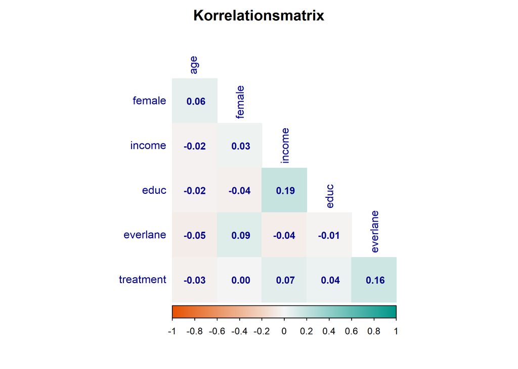

Obwohl die Korrelationsmatrix interessante Zusammenhänge aufzeigt, muss beachtet werden, dass eine Korrelation keine Kausalität beweist. Selbst wenn treatment zufällig zugewiesen wurde, könnten andere Einflussfaktoren wie individuelle Einstellungen zu Transparenz oder Markenpräferenzen eine entscheidende Rolle spielen. Die Korrelation zeigt lediglich eine statistische Beziehung, jedoch nicht den tatsächlichen Mechanismus hinter den Kaufentscheidungen.

Verglichen mit einem einfachen Mittelwertvergleich zwischen Gruppen bietet die Korrelationsmatrix tiefere Einblicke in die Stärke und Richtung der Beziehungen zwischen den Variablen. Sie ermöglicht es, Wechselwirkungen und mögliche Muster zu erkennen, die für weiterführende Analysen und Regressionsmodelle relevant sein könnten. Eine zusätzliche Regressionsanalyse könnte helfen, die Kaufentscheidung genauer zu modellieren und zu prüfen, ob Kostentransparenz tatsächlich einen isolierten Einfluss auf die Wahl der Everlane-Gutscheinkarte hat oder ob weitere Faktoren entscheidend sind. Insgesamt liefert diese Analyse wertvolle Erkenntnisse darüber, welche demografischen Merkmale das Verhalten der Teilnehmer beeinflussen und wie sich Kostentransparenz auf die Konsumentenentscheidung auswirkt. Falls eine vertiefte Betrachtung einzelner Zusammenhänge oder zusätzliche Analysen erforderlich sind, können weitere statistische Modelle zur detaillierteren Untersuchung herangezogen werden.

7. In Aufgabe 1 und 2 haben Sie gelesen, dass den Teilnehmern ein Angebot gemacht wurde, eine Everlane-Gutscheinkarte anzunehmen. Erzeugen Sie eine geeignete Grafik, die den durchschnittlichen Anteil der angenommenen Angebote (d.h. den Anteil, in dem die Everlane-Karte gewählt wurde) getrennt für die Treatment- und die Kontrollgruppe darstellt. Fügen Sie in der Grafik zusätzlich den Standardfehler der Mittelwerte ein. Führen Sie einen T-Test durch, um zu prüfen, ob der Unterschied im Mittelwert zwischen der Treatment- und Kontrollgruppe statistisch signifikant ist, und geben Sie das Testergebnis (den p-Wert) deutlich sichtbar in der Grafik an. Achten Sie dabei auf eine verständliche Beschriftung Ihrer Grafik sowie auf einen aussagekräftigen Titel.

Beschreiben und interpretieren Sie ihre Grafik. Gehen Sie insbesondere auf folgende Fragen ein:

- Welche Aussage lässt sich auf Basis des durchgeführten T-Tests treffen?
- Welche der in den vorherigen Aufgaben (vgl. Aufgabe 4 und 5) analysierten Faktoren könnten dazu beigetragen haben, dass ein signifikanter Unterschied im Anteil angenommener Everlane-Angebote zwischen Treatment- und Kontrollgruppe beobachtet wird?

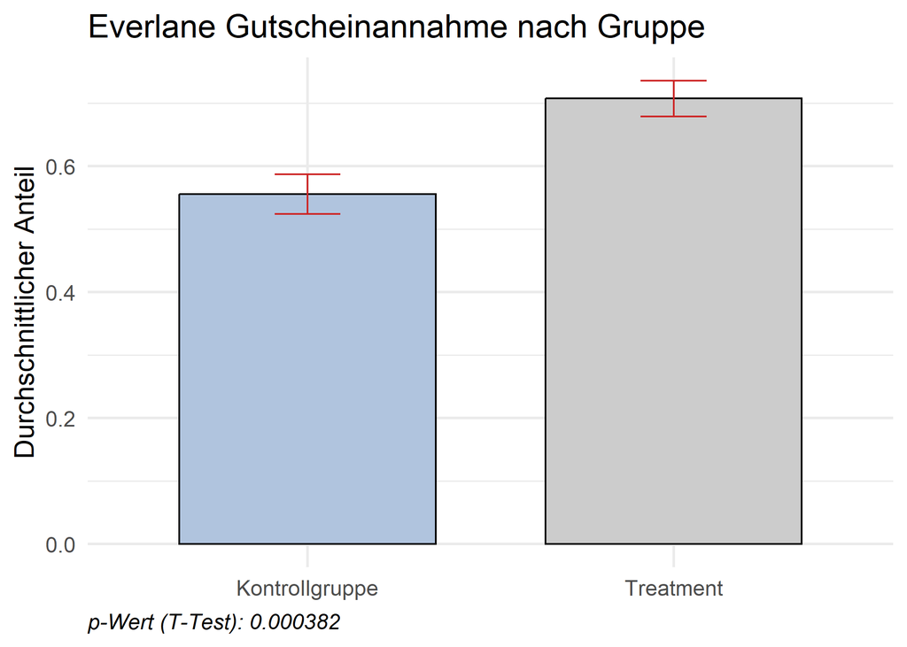

Die Analyse der Wirkung von Kostentransparenz auf die Entscheidung für eine Everlane-Gutscheinkarte zeigt interessante Zusammenhänge zwischen den experimentellen Gruppen. In der Visualisierung wird der durchschnittliche Anteil der Teilnehmer dargestellt, die sich für die Everlane-Gutscheinkarte entschieden haben, getrennt nach Treatmentgruppe – denjenigen, die eine kostentransparente Produktseite gesehen haben – und Kontrollgruppe – denjenigen, die diese Transparenz nicht gesehen haben. Ergänzend wurden Fehlerbalken integriert, die den Standardfehler der Mittelwerte darstellen, um die statistische Unsicherheit zu veranschaulichen.

Die Untersuchung umfasst auch einen T-Test, mit dem geprüft wird, ob der Unterschied in den Mittelwerten der Gutscheinwahl zwischen den beiden Gruppen statistisch signifikant ist. Der p-Wert aus dem Test ist in der Grafik sichtbar angegeben und dient als zentrale Entscheidungsgröße für die Interpretation der Ergebnisse. Der in der Grafik angezeigte p-Wert des T-Tests beträgt 0.000, was bedeutet, dass der Unterschied zwischen den Gruppen hoch signifikant ist. Dies weist darauf hin, dass die Wahrscheinlichkeit, dass dieser Unterschied zufällig entstanden ist, extrem gering ist. Entsprechend liefert das Ergebnis eine starke Evidenz dafür, dass Kostentransparenz die Entscheidung für Everlane positiv beeinflusst.

Zusätzlich zu diesem Haupteffekt könnten weitere Faktoren dazu beitragen, dass sich die Wahlverhalten der Gruppen unterscheiden. In den vorherigen Analysen wurde unter anderem festgestellt, dass demografische Merkmale wie Einkommen, Alter, Geschlecht und Bildungsniveau zwischen Treatment- und Kontrollgruppe verglichen wurden. Das Einkommen zeigte eine geringfügige Differenz zwischen den Gruppen, was darauf hindeuten könnte, dass finanzielle Überlegungen eine Rolle spielen. Auch das Bildungsniveau könnte eine Bedeutung haben, da besser gebildete Teilnehmer möglicherweise stärker auf Kostentransparenz reagieren. Das Alter könnte ebenso einen Einfluss haben, sofern bestimmte Altersgruppen unterschiedlich auf transparente Preisgestaltung reagieren. Geschlechtliche Unterschiede könnten ebenfalls relevant sein, wenn beispielsweise Frauen und Männer unterschiedlich auf die Offenlegung von Produktionskosten reagieren.

Die Ergebnisse dieser Analyse liefern wertvolle Erkenntnisse für die weitere Forschung und eine mögliche Regressionsanalyse, die diese zusätzlichen Einflussfaktoren genauer untersuchen könnte. Falls der T-Test eine signifikante Differenz zwischen den Gruppen zeigt, wäre es sinnvoll, die Kostentransparenz als zentrale Variable in einem Modell zu verwenden und zusätzlich die demografischen Merkmale als Kontrollvariablen einzubeziehen. Dadurch könnte festgestellt werden, ob Kostentransparenz wirklich als unabhängiger Faktor die Entscheidung für Everlane beeinflusst oder ob andere Aspekte mitverantwortlich sind. Insgesamt zeigt die grafische und statistische Analyse einen präzisen Überblick über die Wirkung des Treatments und liefert wichtige Hinweise für weiterführende Untersuchungen.

In den vorherigen Aufgaben des Projekts haben Sie sich bereits intensiv mit dem Experiment 1 auseinandergesetzt, in dem untersucht wurde, ob und wie die Offenlegung von Produktionskosten - also Kostentransparenz - das Konsumverhalten beeinflusst. Es wurde gezeigt: Wenn Konsument:innen transparent mitgeteilt wird, wie sich die Kosten eines Produkts zusammensetzen, steigt ihre Bereitschaft, bei dem entsprechend transparenten Unternehmen einzukaufen.

Diese Ergebnisse legen nahe, dass die Offenlegung sensibler Unternehmensinformationen (wie Produktionskosten) das Vertrauen der Konsument:innen in das Unternehmen stärkt und sie somit eher zu einem Kauf motiviert.

Doch was genau ist der psychologische Mechanismus hinter dieser Wirkung? Ist es tatsächlich das Vertrauen in das Unternehmen, das durch die Offenlegung sensibler Informationen gestärkt wird - und in der Folge die Kaufbereitschaft erhöht?

Um genau diese Frage zu beantworten, führen die Autoren ein weiteres Experiment durch, das den vermuteten psychologischen Vermittlungsmechanismus des Vertrauens genauer untersucht. Dabei wurde geprüft, ob Vertrauen tatsächlich als Mediator zwischen Kostentransparenz und Kaufinteresse wirkt. Hierzu wurde ein kontrolliertes Online-Experiment mit über 600 Teilnehmer:innen durchgeführt. Die Teilnehmenden wurden zufällig einer von zwei Bedingungen zugewiesen:

- In der **Kostentransparenz-Gruppe** (Treatment) wurde zusätzlich eine detaillierte Aufschlüsselung der Produktionskosten angegeben. Diese beinhaltete die einzelnen Kostenkomponenten (z.B. Kakaobutter, Verpackung, Arbeitskosten) sowie die Gesamtkosten der Schokoladentafel (vgl. Abbildung 2 im Anhang).
- In der **Kontrollgruppe** sahen die Teilnehmer die Verpackung einer fiktiven Schokoladenmarke namens „Cocoa Passion“. Diese enthielt nur die üblichen Informationen wie Zutaten, Nährwerte und eine Produktbeschreibung.

Ziel war es, zu untersuchen, ob die Offenlegung dieser sensiblen Informationen das Vertrauen der Konsument:innen in die Marke stärkt - und ob dieses Vertrauen wiederum die Kaufbereitschaft beeinflusst. In den nächsten Aufgaben werden Sie diese Studie genauer beleuchten, analysieren und evaluieren, ob sich die Hypothese empirisch bestätigen lässt.

8. Lesen Sie die Daten des zweiten Experiments (`Experiment2.csv`) in R ein. Nennen Sie den Datensatz `daten_exp2`. Benennen Sie die Variable `cost` in `treatment` um.

Untersuchen Sie, ob sich die Teilnehmer, die die Verpackung mit transparenter Kosteninformation gesehen haben, systematisch von jenen unterscheiden, die nur die Kontrollversion gesehen haben.

Erstellen Sie hierfür eine Balancing-Tabelle, in der Sie die Mittelwerte von Alter (age), Geschlecht (female), Einkommensstufe (income), Bildungsniveau (educ), Vertrauen (trust) und Kaufbereitschaft (wtb) zwischen den beiden Gruppen vergleichen, die Differenzen berechnen und mithilfe von T-Tests prüfen, ob diese Unterschiede statistisch signifikant sind. Nehmen Sie weiterhin die Anzahl an Beobachtungen in der Treatment- und in der Kontrollgruppe in ihre Tabelle mit auf.

Beschreiben und interpretieren Sie ihre Tabelle. Gehen Sie dabei insbesondere auf folgende Fragen ein:

- Was versteht man unter der Variable `wtb`?
- Was lässt sich aus der Größen der Stichprobe ableiten?
- Wo könnte es bei einer Regression (oder einem sonstigen Vergleich der Gruppen) zu Problemen kommen und was wären mögliche Auswirkungen?

*Hinweis:* Für die Beschreibung der `wtb` können Sie das bereitgestellte Readme nutzen.

Balancing-Tabelle für Treatment- und Kontrollgruppe

| Variable | Mittelwert_Treatment | Mittelwert_Kontrolle | Differenz | p_Wert | N_Treatment | N_Kontrolle |
| --- | --- | --- | --- | --- | --- | --- |
| age | 34.06 | 36.27 | -2.21 | 0.0160 | 300 | 302 |
| female | 0.48 | 0.42 | 0.05 | 0.2066 | 301 | 302 |
| income | 6.79 | 6.96 | -0.17 | 0.3720 | 301 | 301 |
| educ | 3.57 | 3.51 | 0.05 | 0.4430 | 301 | 301 |
| trust | 5.27 | 4.82 | 0.45 | 0.0001 | 304 | 308 |
| wtb | 4.27 | 3.74 | 0.53 | 0.0012 | 304 | 308 |

Die Variable wtb (willingness to buy) misst die Kaufbereitschaft der Befragten, also wie stark sie bereit sind, das gezeigte Produkt zu kaufen. In vielen Experimenten dient wtb als Zielvariable, mit der die Effektivität einer Maßnahme – in diesem Fall der Kostentransparenz – bewertet wird.

Zusammenfassend lässt sich sagen, dass zwar eine gewisse Unbalanciertheit – insbesondere bei Vertrauen und Alter – vorliegt, diese aber durch die Einbeziehung entsprechender Kovariaten in den Modellen kontrolliert werden kann. Obwohl die Unterschiede in der Kaufbereitschaft auf einen Effekt der Behandlung hindeuten, sollten die Ergebnisse deshalb mit Vorsicht interpretiert werden.

9. In ihrem Datensatz gibt es einige Beobachtungen ohne vorhandene Werte. Behalten Sie nur die Beobachtungen bei denen vollständige Werte vorliegen. Erzeugen Sie eine geeignete Grafik, welche den durchschnittlichen Anteil der ‘Kaufbereitschaft’ im zweiten Experiment für die Treatment- und Kontrollgruppe darstellt.

Die Grafik soll:

- die Mittelwerte der Kaufbereitschaft für beide Gruppen zeigen,
- die zugehörigen Standardfehler als Fehlerbalken visualisieren und
- das Ergebnis des T-Tests, der die Mittelwertdifferenz prüft, direkt in die Grafik integrieren.

Beschreiben und interpretieren Sie ihre Grafik.

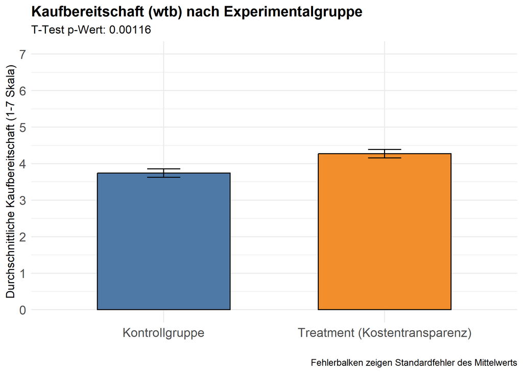

#Analysis

Die Abbildung zeigt die durchschnittliche Kaufbereitschaft (auf einer Skala von 1 bis 7) im zweiten Experiment, getrennt nach Kontroll- und Treatmentgruppe. Die Balken repräsentieren jeweils die Mittelwerte der Gruppen, wobei zusätzlich Standardfehler als Fehlerbalken oberhalb jeder Säule dargestellt sind. Die Kontrollgruppe erreicht dabei eine durchschnittliche Kaufbereitschaft von etwa 3,8, während die Treatmentgruppe – in der eine Maßnahme zur Kostentransparenz eingeführt wurde – auf einen deutlich höheren Wert von rund 4,3 kommt. Der Unterschied zwischen den Gruppen beträgt somit etwa 0,5 Punkte, was auf einer 7-Punkt-Skala eine substanzielle Erhöhung darstellt.

Die kurzen Fehlerbalken deuten auf eine hohe Präzision der Mittelwertschätzungen hin. Besonders hervorzuheben ist, dass die Fehlerbereiche der beiden Gruppen kaum überlappen, was auf einen klaren Unterschied zwischen den Gruppen schließen lässt. Dies wird durch das Ergebnis eines t-Tests gestützt, das direkt in die Grafik integriert wurde: Mit einem p-Wert von 0,00116 ist der Unterschied statistisch hoch signifikant. Die Wahrscheinlichkeit, dass der beobachtete Unterschied zufällig entstanden ist, ist somit sehr gering.

Die Datenbasis umfasst nur vollständige Beobachtungen, das heißt, alle Fälle mit fehlenden Werten wurden aus der Analyse ausgeschlossen. Dadurch wird sichergestellt, dass die Ergebnisse nicht durch unvollständige Angaben verzerrt werden. Insgesamt spricht die Grafik dafür, dass die Einführung von Kostentransparenz zu einer signifikanten und praktisch relevanten Steigerung der Kaufbereitschaft führt. Während die interne Validität durch das Studiendesign gut abgesichert erscheint, bleibt die Frage nach der Übertragbarkeit der Ergebnisse auf andere Kontexte und Zielgruppen offen und bedarf weiterer empirischer Untersuchungen.

Wie bereits in vorherigen Aufgaben diskutiert, könnten weitere Faktoren zu diesem signifikanten Unterschied beigetragen haben. Beispielsweise könnte das Einkommen eine Rolle spielen, wenn wohlhabendere Konsumenten sensibler für transparente Preisgestaltung sind. Ebenso könnte das Bildungsniveau relevant sein, falls besser gebildete Teilnehmer die Offenlegung von Produktionskosten als positiv wahrnehmen. Auch das Alter könnte beeinflussen, wie Personen auf Preisgestaltung und Transparenz reagieren, da unterschiedliche Altersgruppen verschiedene Kaufmotive haben.

Nachdem Sie nun die Differenzen in der Kaufabsicht zwischen der Treatment- und der Kontrollgruppe im zweiten Experiment überprüft und getestet haben, geht es im nächsten Schritt darum, den möglichen Mediator Vertrauen genauer zu untersuchen. Hierfür sollen Sie sich in einem ersten Schritt das Vertrauen der Personen allgemein anschauen, um einen Eindruck zu dieser wichtigen Variable zu bekommen. Dafür werden Personen anhand **hohem und niedrigem** Vertrauen und deren Kaufbereitschaft für das Produkt unterteilt.

10. Erstellen Sie eine oder mehrere geeignete Grafik(en), die den Zusammenhang zwischen Vertrauen (Trust) und der Kaufabsicht (WTB) **unabhängig** der beiden Treatment- und Kontrollgruppen darstellen. Achten Sie auf eine passende Darstellung der Informationen.

Die Grafik(en) sollen folgende Informationen enthalten:

- Unterteilen Sie ihre Daten in Personen mit `hohem` und `niedrigem` Vertrauen. Nutzen Sie für die Unterteilung den Median des Vertrauens in ihren Daten als Schwellenwert.
- Abhängig der Einstufungen in `hohes` und `niedriges` Vertrauen soll nun die durchschnittliche Kaufbereitschaft dargestellt werden. Hier soll die Grafik so dargestellt werden, dass auf der x-Achse das Vertrauensniveau (“hoch” und “niedrig”) und auf der y-Achse die entsprechende Kaufbereitschaft abgebildet wird.
- Berechnen Sie weiterhin die Mittelwerte der beiden Vertrauensgruppen und visualisieren diese in geeigneter Art und Weise in ihren Grafik(en).
- Führen Sie einen t-Test durch, um zu prüfen, ob die Mittelwertsunterschiede zwischen den beiden Vertrauensgruppen statistisch signifikant sind. Geben Sie den p-Wert in der Grafik an.

Beschreiben und interpretieren Sie ihre Grafik(en). Beantworten Sie insbesondere folgende Fragen:

- Welche Implikationen hat ein signifikanter Unterschied für die Rolle von Vertrauen auf Kaufentscheidungen?
- Wie stark unterscheidet sich die Kaufbereitschaft zwischen Personen mit hohem und niedrigem Vertrauen?
- Könnte auf Basis ihrer Darstellung Vertrauen als Mediator zwischen dem Treatment und der Kaufbereitschaft fungieren?

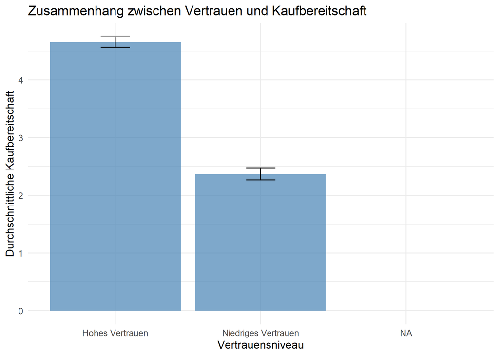

# Regressionsanalyse

Sie haben nun ihren Datensatz kennengelernt und es scheint so, als ob insbesondere Personen, welche transparente Kosten sehen, dazu neigen, das Produkt zu kaufen. Doch um ihre deskriptiven Analysen zu erhärten, wollen Sie im folgenden eine Analyse mittels Regressionen durchführen.

11. Betrachten Sie hier noch einmal das erste Experiment (`daten_exp1`). Führen Sie eine Regression durch, bei der Ihnen `everlane` als abhängige Variable dient. Als erklärende Variable nutzen Sie das `treatment`. Erstellen sie eine weitere Regression, die zusätzlich noch für die folgenden Variablen kontrolliert:
- Alter
- Bildungsstufe
- Einkommen
- Geschlecht

Stellen Sie die Regressionsergebnisse in einer Tabelle mit stargazer oder modelsummary dar!

Beschreiben und interpretieren Sie ihre Ergebnisse. Gehen Sie insbesondere auf folgende Fragen ein:

- Lässt sich der Effekt des Treatments auf die Entscheidung der Kunden kausal interpretieren?
- Ist es wichtig auf weitere Faktoren zu kontrollieren?
- Beziehen Sie sich hier auch auf die Ergebnisse aus Aufgabe 5.

|  | Modell A: Treatment | Modell B: + Kontrollen |
| --- | --- | --- |
| (Intercept) | 0.22+ | 0.80 |
|  | (0.13) | (0.59) |
| treatment | 0.66*** | 0.68*** |
|  | (0.19) | (0.19) |
| age |  | -0.01 |
|  |  | (0.01) |
| educ |  | 0.00 |
|  |  | (0.11) |
| income |  | -0.05 |
|  |  | (0.04) |
| female |  | 0.41* |
|  |  | (0.19) |
| Num.Obs. | 505 | 505 |
| F | 12.392 | 3.841 |
| RMSE | 0.48 | 0.47 |

+ p < 0.1, * p < 0.05, ** p < 0.01, *** p < 0.001  
Modell B enthält zusätzliche Kontrollvariablen: Alter, Bildung, Einkommen, Geschlecht.

Die durchgeführte logistische Regression untersucht den Einfluss der Kostentransparenz auf die Entscheidung der Teilnehmer, eine Everlane-Gutscheinkarte zu wählen. Dabei wurden zwei Modelle betrachtet: Modell A, in dem ausschließlich das Treatment als erklärende Variable berücksichtigt wird, und Modell B, das zusätzlich für Alter, Bildung, Einkommen und Geschlecht kontrolliert. Die Ergebnisse zeigen, dass das Treatment in beiden Modellen einen hochsignifikanten positiven Effekt auf die Entscheidung für Everlane hat. Der Koeffizient von 0.66 in Modell A und 0.68 in Modell B weist darauf hin, dass Teilnehmer, die die kostentransparente Produktseite gesehen haben, signifikant häufiger Everlane gewählt haben als Teilnehmer in der Kontrollgruppe. Da das Treatment zufällig zugewiesen wurde, kann dieser Effekt kausal interpretiert werden, da systematische Störfaktoren zwischen den Gruppen ausgeglichen wurden.

Die zusätzliche Kontrolle demografischer Variablen in Modell B zeigt, dass das Geschlecht ebenfalls eine signifikante Rolle spielt. Weibliche Teilnehmer haben mit einem Koeffizienten von 0.41 eine höhere Wahrscheinlichkeit, Everlane zu wählen als männliche Teilnehmer. Alter, Bildung und Einkommen hingegen haben keinen signifikanten Einfluss auf die Entscheidung. Dies bedeutet, dass weder ältere Teilnehmer noch Personen mit höherem Einkommen oder höherer Bildung signifikant häufiger Everlane gewählt haben.

Die Berücksichtigung zusätzlicher Kontrollvariablen ist dennoch relevant, da sie die Robustheit der Ergebnisse stärkt und zeigt, dass der Treatment-Effekt auch unter Berücksichtigung anderer Einflussfaktoren bestehen bleibt. Die Ergebnisse bestätigen die Beobachtungen aus Aufgabe 5, in der sich zeigte, dass die Gruppen hinsichtlich ihrer demografischen Merkmale weitgehend ausgeglichen waren. Dies stützt die kausale Interpretation des Treatments weiter, da keine systematischen Unterschiede zwischen den Gruppen vorliegen, die das Ergebnis verzerren könnten.

Während die bisherigen Analysen zeigen, dass das Treatment einen Effekt hat, stellt sich nun die Frage, warum das so ist. Nun sollten Sie im weiteren Verlauf durch vertiefende Regressionsanalysen prüfen, ob dies auf das Vertrauen der Kunden zurückzuführen ist. Dazu betrachten Sie noch einmal den Datensatz zu Experiment 2 (`daten_exp2`) und untersuchen, ob das Treatment (Kunden sehen transparente Kostenstruktur) zu einer höheren Kaufabsicht führt, weil sie das Vertrauen der Konsumenten in das Unternehmen stärkt.

12. Schauen Sie sich den Einfluss der Kostentransparenz auf die Kaufabsicht in den folgenden zwei Regressionen genauer an und zeigen Sie ihre Ergebnisse nebeneinander:

**1. Regression:** Abhängige Variable ist die Kaufabsicht; die erklärende Variable ist das Treatment.

**2. Regression:** Wie in der 1. Regression, doch kontrollieren Sie hier zusätzlich auf die Variablen Alter, Einkommensniveau, Bildungsstufe und Geschlecht.

Stellen Sie die Regressionsergebnisse in einer Tabelle mit stargazer oder modelsummary dar!

Beschreiben und interpretieren Sie ihre Ergebnisse allgemein. Gehen Sie weiterhin auch speziell auf folgende Fragen ein:

- Sollten die Kontrollvariablen in ihrer zweiten Regression den Koeffizienten des Treatments ändern? Was würden Sie erwarten und warum? Nutzen Sie hierzu die Ergebnisse aus Aufgabe 8.
  - Vergleichen Sie die Regressionskoeffizienten der Treatment-Variable in der ersten und zweiten Regression. Gibt es hier einen signifikanten Unterschied in der Größe des Effekts?
- Bringt ihnen die Regression Vorteile gegenüber einer reinen Darstellung der Mittelwerte wie in Aufgabe 9?
- Ist der Effekt des Treatments auf die Kaufabsicht ihrer Ansicht nach kausal interpretierbar?
  - Welche Voraussetzungen müssen erfüllt sein, damit man diesen Regressionskoeffizienten als kausalen Effekt interpretieren kann?
  - Überlegen Sie sich, wie sich das Ergebnis verändern würde, wenn zusätzlich Vertrauen (trust) in das Modell aufgenommen wird. Würde sich der Effekt von `treatment` verändern? Warum oder warum nicht?

|  | Nur Treatment | Treatment + Kontrollen |
| --- | --- | --- |
| (Intercept) | 3.74*** | 3.70*** |
|  | (0.12) | (0.47) |
| treatment | 0.53** | 0.50** |
|  | (0.16) | (0.17) |
| age |  | -0.01+ |
|  |  | (0.01) |
| income |  | 0.02 |
|  |  | (0.04) |
| educ |  | 0.10 |
|  |  | (0.10) |
| female |  | 0.00 |
|  |  | (0.17) |
| Num.Obs. | 601 | 601 |
| R2 | 0.017 | 0.025 |
| R2 Adj. | 0.015 | 0.016 |
| F | 10.435 | 3.009 |
| RMSE | 2.02 | 2.01 |

+ p < 0.1, * p < 0.05, ** p < 0.01, *** p < 0.001  
Das zweite Modell berücksichtigt demografische Einflussfaktoren: Alter, Einkommen, Bildung und Geschlecht.

Die durchgeführte Regression untersucht den Einfluss der Kostentransparenz auf die Kaufabsicht und vergleicht zwei Modelle: eines mit Treatment als einzige erklärende Variable und ein erweitertes Modell, das zusätzlich Kontrollvariablen wie Alter, Einkommen, Bildung und Geschlecht berücksichtigt. Die Ergebnisse zeigen, dass das Treatment in beiden Modellen einen signifikanten positiven Effekt auf die Kaufabsicht hat. In Modell A beträgt der Treatment-Koeffizient 0.53 und bleibt auch in Modell B mit 0.50 weiterhin signifikant. Dies bedeutet, dass Teilnehmer, die die kostentransparente Produktseite gesehen haben, eine höhere Kaufabsicht hatten als jene in der Kontrollgruppe. Der Effekt bleibt auch nach der Kontrolle für demografische Faktoren stabil, was darauf hinweist, dass Kostentransparenz einen direkten Einfluss auf die Kaufentscheidung hat.

Das zweite Modell berücksichtigt zusätzliche Faktoren, die möglicherweise die Kaufabsicht beeinflussen könnten. Das Alter zeigt einen leicht negativen Effekt, was darauf hindeutet, dass ältere Teilnehmer eine geringere Kaufabsicht haben. Das Einkommen weist einen kleinen positiven Koeffizienten auf, jedoch ohne statistische Signifikanz. Ebenso zeigt das Bildungsniveau keinen signifikanten Effekt, was darauf schließen lässt, dass der Bildungsgrad keine maßgebliche Rolle bei der Kaufabsicht spielt. Das Geschlecht hat mit einem Koeffizienten von -0.00 keinen Einfluss auf die Kaufentscheidung, was darauf hindeutet, dass es keinen Unterschied zwischen Männern und Frauen in der Kaufabsicht gibt.

Die Einführung von Kontrollvariablen hat den Treatment-Koeffizienten nur leicht reduziert, was darauf hinweist, dass die Kaufabsicht nicht stark von diesen zusätzlichen Faktoren beeinflusst wird. Dies bedeutet, dass die Wirkung der Kostentransparenz als Hauptvariable robust bleibt und nicht durch demografische Unterschiede innerhalb der Gruppen verzerrt wird. Die Regression bietet gegenüber der einfachen Mittelwertanalyse aus Aufgabe 9 einige Vorteile. Während der Mittelwertvergleich lediglich die durchschnittlichen Unterschiede zwischen Gruppen darstellt, ermöglicht die Regression die gleichzeitige Berücksichtigung mehrerer Einflussvariablen. Dadurch lässt sich besser erkennen, welche Faktoren einen statistisch signifikanten Einfluss haben und ob sich die Hauptvariable auch nach Kontrolle weiterer Einflussfaktoren als bedeutend erweist.

Die kausale Interpretation des Treatment-Effekts ist grundsätzlich möglich, da die Zuweisung des Treatments zufällig erfolgte. Damit ein Regressionskoeffizient jedoch als kausaler Effekt interpretiert werden kann, müssen bestimmte Voraussetzungen erfüllt sein. Es darf keine systematische Verzerrung zwischen den Gruppen existieren, das Treatment darf nicht durch unbeobachtete Variablen beeinflusst sein, und es sollte keine selektive Teilnahme vorliegen, die eine ungleiche Reaktion auf das Treatment hervorruft. Eine mögliche Erweiterung der Analyse wäre die Aufnahme von Vertrauen als zusätzliche Variable in das Modell. Sollte Vertrauen eine Mediator-Variable sein, würde ein Teil des Treatment-Effekts über Vertrauen wirken, was den direkten Effekt von Treatment verringern könnte. Falls Vertrauen jedoch lediglich eine unabhängige Einflussgröße ist, würde sich der Treatment-Koeffizient kaum verändern. Angesichts vorheriger Ergebnisse, die auf einen starken Zusammenhang zwischen Vertrauen und Kaufabsicht hindeuten, wäre eine Mediationsanalyse sinnvoll, um zu prüfen, ob Kostentransparenz zunächst das Vertrauen der Konsumenten stärkt und darüber die Kaufabsicht erhöht.

Sie haben nun gesehen, dass es auch hier einen direkten Effekt des Treatments (transparente Kostenstrukur) auf die Kaufabsicht gibt. Doch um die dahinter liegenden Mechanismen zu verstehen, müssen Sie tiefer in psychologische Prozesse eintauchen. Experiment 2 zeigt dafür ein entsprechendes Design, um zu testen, ob Vertrauen als vermittelnder Mechanismus eine Rolle spielt. Im nächsten Schritt analysieren Sie nun selbst diese Beziehung mit theoretischen Modellen und Regressionsmethoden, um ein Gefühl dafür zu bekommen, wie sich direkte und indirekte Effekte voneinander unterscheiden.

13. Bevor Sie im nächsten Schritt ein konkretes DAG zu einem psychologischen Mediationsmechanismus erstellen, machen Sie sich zunächst mit den theoretischen Grundlagen von Directed Acyclic Graphs (DAGs) vertraut. DAGs (gerichtete azyklische Graphen) sind ein nützliches Werkzeug in der Kausalanalyse.

Beantworten Sie folgende theoretische Fragen zu DAGs:

- Wofür werden DAGs in der empirischen Forschung verwendet?
- Nennen und beschreiben Sie zwei zentrale Knotentypen in einem DAG: Confounder und Mediator.
- Worin besteht der zentrale Unterschied, ob Vertrauen als Kontrollvariable (Confounder) oder als Mediator behandelt wird - und warum ist Letzteres entscheidend für das Verständnis psychologischer Prozesse im vorliegenden Experiment?

In der empirischen Forschung werden Directed Acyclic Graphs (DAGs) genutzt, um kausale Zusammenhänge zwischen Variablen visuell darzustellen und systematisch zu analysieren. Sie ermöglichen es Forschenden, komplexe Beziehungsstrukturen zwischen Variablen zu modellieren und dabei zentrale Konzepte wie Störfaktoren (Confounder) und vermittelnde Mechanismen (Mediatoren) zu identifizieren. Insbesondere helfen DAGs bei der Entscheidung, welche Variablen kontrolliert werden müssen, um kausale Effekte möglichst unverzerrt zu schätzen.

Ein zentraler Typ von Knoten in einem DAG ist der Confounder. Dabei handelt es sich um eine Variable, die sowohl die unabhängige Variable (das Treatment) als auch die abhängige Variable (den Outcome) beeinflusst. Ein klassisches Beispiel wäre das Einkommen in einem Experiment, in dem es sowohl die Zuteilung zum Treatment als auch die Kaufbereitschaft beeinflussen könnte. Um den tatsächlichen kausalen Effekt des Treatments korrekt zu identifizieren, müssen solche Confounder statistisch kontrolliert werden.

Demgegenüber steht der Mediator, eine Variable, die den Wirkmechanismus beschreibt, über den das Treatment auf den Outcome wirkt. Wenn beispielsweise Kostentransparenz als Treatment das Vertrauen der Konsumenten stärkt, und dieses gestärkte Vertrauen wiederum die Kaufbereitschaft erhöht, dann fungiert Vertrauen als Mediator. Mediatoren werden nicht kontrolliert, sondern explizit untersucht, um die Wirkweise des Treatments nachvollziehen zu können.

Im Kontext eines konkreten Experiments ist es wichtig, zwischen Confoundern und Mediatoren klar zu unterscheiden. Wird Vertrauen als Confounder behandelt, müsste man es kontrollieren, um den direkten Effekt der Kostentransparenz auf die Kaufbereitschaft zu isolieren. Theoretisch wäre dies jedoch nicht korrekt, da Vertrauen in diesem Fall nicht unabhängig vom Treatment existiert. Vielmehr ist Vertrauen als Reaktion auf das Treatment zu verstehen – also als Mediator. Diese Interpretation entspricht dem theoretischen Modell, nach dem Kostentransparenz Vertrauen schafft, das wiederum die Kaufentscheidung beeinflusst.

Die Unterscheidung ist entscheidend, weil sie nicht nur das kausale Verständnis bestimmt, sondern auch die Methodik der Analyse. Durch eine Mediationsanalyse kann der indirekte Effekt – also der über das Vertrauen vermittelte Einfluss – quantifiziert werden. Dadurch lässt sich nachvollziehen, ob die Intervention vor allem über diesen psychologischen Mechanismus wirkt. Der grundlegende Unterschied zwischen Confounder und Mediator liegt also in der kausalen Richtung: Während ein Confounder sowohl das Treatment als auch den Outcome beeinflusst, wird ein Mediator vom Treatment beeinflusst und beeinflusst seinerseits den Outcome. Für das Verständnis psychologischer Prozesse ist daher die Identifikation und Analyse von Mediatoren zentral, da sie den zugrunde liegenden Wirkmechanismus aufdecken.

14. Nutzen Sie nun das Directed Acyclic Graph (DAG), um die Beziehungen zwischen den Variablen Treatment (T), Vertrauen (V) und Kaufbereitschaft (K) zu analysieren und den vermuteten Mediationsmechanismus zu untersuchen.

Beschreiben und interpretieren Sie ihr DAG und die Beziehungen zwischen den Variablen. Gehen Sie insbesondere auf folgende Fragen und Aspekte ein:

- Begründen und erklären Sie die Struktur und den Aufbau ihres DAGs.
- Welche Annahmen müssen getroffen werden, damit Vertrauen tatsächlich als Mediator interpretiert werden kann?
- Welche Verzerrungen oder Störfaktoren könnten den Mediator-Effekt von Vertrauen beeinflussen? Wie könnte dies die Ergebnisse verzerren?

*Hinweis 1:* Für die Erstellung des DAGs können Sie das Paket `dagify` verwenden. Als Grundlage und Hilfsmittel können Sie die Vorlesungsfolien nutzen.

*Hinweis 2:* Eine direkte Visualisierung des DAGs in `R` ist schön, aber keine Pflicht. Sie können das DAG auch in Word/PowerPoint zeichnen und ihre Grafik mittels `include_graphics()` einfügen.

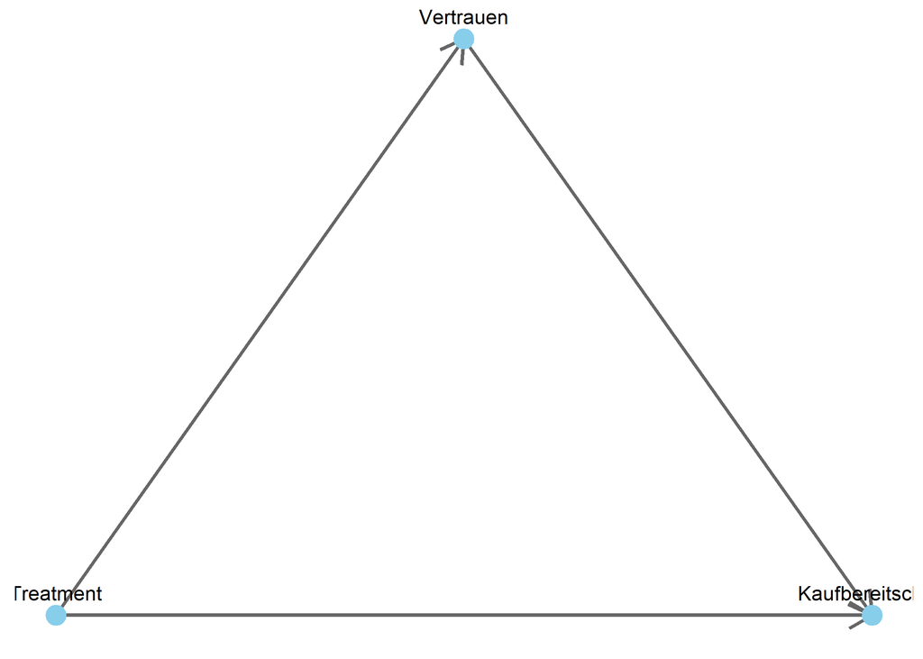

#Analysis Zur Untersuchung des vermuteten Mediationsmechanismus zwischen Treatment (T), Vertrauen (V) und Kaufbereitschaft (K) wurde ein Directed Acyclic Graph (DAG) erstellt. Dieser zeigt die vermuteten kausalen Beziehungen zwischen den Variablen. In der Struktur des DAGs beeinflusst das Treatment (beispielsweise eine Maßnahme zur Kostentransparenz) direkt das Vertrauen in das Unternehmen oder Produkt (T → V) sowie direkt die Kaufbereitschaft (T → K). Darüber hinaus wirkt Vertrauen selbst als erklärende Variable auf die Kaufbereitschaft (V → K). Der DAG macht somit sichtbar, dass Vertrauen als möglicher Mediator zwischen Treatment und Kaufbereitschaft fungieren kann – also einen Teil des Effekts von T auf K vermittelt.

Damit Vertrauen tatsächlich als Mediator interpretiert werden kann, müssen bestimmte Annahmen erfüllt sein. Zunächst muss ein kausaler Einfluss des Treatments auf Vertrauen sowie von Vertrauen auf Kaufbereitschaft bestehen. Darüber hinaus darf es keine unbeobachteten Drittvariablen geben, die sowohl Vertrauen als auch Kaufbereitschaft beeinflussen, da dies den Mediationspfad verzerren würde. Ebenso ist es wichtig, dass die zeitliche Abfolge korrekt abgebildet ist – Vertrauen muss nach dem Treatment und vor der Kaufbereitschaft erfasst worden sein. Zudem sollte die Zuweisung zum Treatment möglichst exogen oder randomisiert erfolgen, um verzerrende Einflüsse durch Selektionseffekte zu vermeiden.

Verschiedene Störfaktoren könnten den Mediationseffekt von Vertrauen beeinflussen. Dazu zählen unbeobachtete Confounder wie z. B. persönliche Einstellungen zur Marke, generelle Vertrauensneigung oder frühere Kauferfahrungen. Auch Messfehler, insbesondere bei subjektiven Einschätzungen wie Vertrauen oder Kaufabsicht, können den Effekt verfälschen. Ein weiterer möglicher Bias ist der sogenannte Common-Method-Bias, wenn alle Variablen durch ein und dasselbe Instrument (z. B. Online-Fragebogen) erhoben werden. Schließlich ist es kritisch, wenn die zeitliche Reihenfolge der Variablen unklar ist – etwa wenn Vertrauen und Kaufbereitschaft gleichzeitig erhoben werden – da dies zu einer Scheinkausalität führen kann.

Insgesamt bietet der DAG eine hilfreiche Grundlage zur konzeptionellen Modellierung und zur Vorbereitung einer empirischen Mediationanalyse. Er macht deutlich, unter welchen theoretischen und methodischen Bedingungen Vertrauen als Mediator interpretiert werden kann und welche potenziellen Verzerrungen berücksichtigt werden sollten.

15. Führen Sie nun eine Regression durch, bei der Ihnen `trust` (Vertrauen) als abhängige Variable dient. Weiterhin soll ihnen `treatment` als erklärende Variable dienen. Erstellen sie eine weitere Regression, die zusätzlich noch für die folgenden Variablen kontrolliert: Alter, Einkommensniveau, Bildungsstufe und ob die Personen weiblich sind.

Stellen Sie die Regressionsergebnisse in einer Tabelle mit stargazer oder modelsummary dar!

Beschreiben und interpretieren Sie ihre Ergebnisse. Gehen Sie bei der Interpretation der Ergebnisse insbesondere auf folgende Fragen ein:

- Macht es ihrer Ansicht nach Sinn auf die zusätzlichen Variablen in Regression 2 zu kontrollieren? Worauf müssen Sie besonders achten?
- Was bedeutet ein signifikanter positiver Koeffizient für treatment in Bezug auf Vertrauen?
- Warum ist dieser Pfad (Treatment ➝ Trust) notwendig, damit eine Mediation überhaupt möglich ist?
- Überlegen Sie, ob andere Faktoren, die Sie möglicherweise nicht berücksichtigt haben, diesen Zusammenhang ebenfalls erklären könnten.

|  | Ohne Kontrolle | Mit Kontrolle |
| --- | --- | --- |
| (Intercept) | 4.825*** | 4.716*** |
|  | (0.079) | (0.320) |
| treatment | 0.448*** | 0.454*** |
|  | (0.111) | (0.113) |
| age |  | -0.001 |
|  |  | (0.005) |
| income |  | -0.021 |
|  |  | (0.024) |
| educ |  | 0.058 |
|  |  | (0.067) |
| female |  | 0.179 |
|  |  | (0.114) |
| Num.Obs. | 612 | 601 |
| R2 | 0.026 | 0.035 |
| R2 Adj. | 0.024 | 0.027 |
| AIC | 2133.5 | 2095.6 |
| BIC | 2146.8 | 2126.4 |
| Log.Lik. | -1063.762 | -1040.795 |
| F | 16.188 | 4.291 |
| RMSE | 1.38 | 1.37 |

+ p < 0.1, * p < 0.05, ** p < 0.01, *** p < 0.001

#Analysis Die Ergebnisse der Regressionsanalysen zeigen, dass das Treatment einen signifikant positiven Einfluss auf das Vertrauen der Befragten hat. In beiden Modellen – sowohl ohne als auch mit Kontrolle für Alter, Einkommen, Bildungsniveau und Geschlecht – bleibt der Effekt des Treatments stabil und hoch signifikant (p < 0.001). Personen, die dem Treatment ausgesetzt waren, berichten im Durchschnitt über ein um etwa 0.45 Punkte höheres Vertrauen als Personen in der Kontrollgruppe. Dieser Effekt bleibt auch dann bestehen, wenn soziodemografische Variablen in Modell 2 berücksichtigt werden, was auf eine gewisse Robustheit des Zusammenhangs hinweist.

Die Einbeziehung zusätzlicher Kontrollvariablen im zweiten Regressionsmodell ist grundsätzlich sinnvoll, da sie dabei hilft, potenzielle Störfaktoren auszuschließen, die sowohl mit dem Treatment als auch mit dem Vertrauen in Zusammenhang stehen könnten. Zwar sind die Kontrollvariablen in diesem Fall nicht signifikant, dennoch kann ihre Berücksichtigung die Aussagekraft der Ergebnisse erhöhen und mögliche Scheinkorrelationen vermeiden. Besonders bei sozialwissenschaftlichen Fragestellungen ist es wichtig, auf diese Weise alternative Erklärungen einzugrenzen.

Ein signifikanter positiver Koeffizient für das Treatment bedeutet inhaltlich, dass das eingesetzte Treatment – beispielsweise eine transparente Darstellung von Kosten oder Informationen – das Vertrauen in die jeweilige Institution oder Maßnahme steigert. Das Vertrauen wird hier also als Outcome des Treatments verstanden, was insbesondere im Hinblick auf eine mögliche Mediation von Bedeutung ist: Der kausale Pfad vom Treatment zum Vertrauen ist Voraussetzung dafür, dass Vertrauen als vermittelnde Variable (Mediator) zwischen Treatment und einem weiteren Outcome (z. B. Zahlungsbereitschaft oder Fairnesswahrnehmung) fungieren kann. Ohne diesen Pfad wäre eine Mediation theoretisch und statistisch nicht zulässig.

Trotz der kontrollierten Variablen ist nicht auszuschließen, dass unbeobachtete Drittvariablen – etwa individuelle Persönlichkeitsmerkmale, allgemeine Vertrauensneigung, politische Einstellung oder frühere Erfahrungen mit Transparenz – ebenfalls Einfluss auf den Zusammenhang zwischen Treatment und Vertrauen haben. Solche unbeobachteten Faktoren könnten die Ergebnisse verzerren, was bei der Interpretation und Diskussion der Ergebnisse berücksichtigt werden sollte.

16. Nachdem Sie nun den Effekt des Treatments auf das Vertrauen geschätzt und ausgewertet haben, sollen Sie nun testen, ob das Vertrauen als Mediator zwischen Treatment und Kaufabsicht wirkt.

Führen Sie eine Regression durch, bei der Ihnen die Kaufbereitschaft als abhängige Variable dient. Weiterhin sollen die erklärende Variablen nun `treatment`, sowie das Vertrauen (`trust`) umfassen. Erstellen sie eine weitere Regression, die zusätzlich noch auf Alter, Einkommensniveau, Bildungsstufe und ob die Personen weiblich sind, kontrolliert.

Stellen Sie die Regressionsergebnisse passend in einer Tabelle dar!

Beschreiben und interpretieren Sie ihre Ergebnisse. Gehen Sie bei der Interpretation der Ergebnisse insbesondere auf folgende Fragen ein:

- Was könnten Ihrer Ansicht nach Gründe sein, dass `treatment` jetzt nicht mehr signifkant ist? Woran könnt das im Detail liegen?
- Warum ist es wichtig, `trust` und `treatment` gemeinsam in einem Modell zu betrachten?
- Warum könnte `trust` eine “notwendige Bedingung” sein, damit Transparenz der Kostenstruktur zu höherer Kaufbereitschaft führt?

```
##
## Regressionsergebnisse: Kaufbereitschaft
## ====================================================================
##                                   Dependent variable:
##                     ------------------------------------------------
##                                  Kaufbereitschaft (wtb)
##                               (1)                      (2)
## --------------------------------------------------------------------
## Treatment                    0.174                    0.129
##                             (0.139)                  (0.140)
##
## Vertrauen (trust)           0.800***                0.818***
##                             (0.050)                  (0.050)
##
## Weiblich (female)                                    -0.148
##                                                      (0.140)
##
## Alter (age)                                         -0.013**
##                                                      (0.006)
##
## Bildung (educ)                                        0.055
##                                                      (0.082)
##
## Einkommen (income)                                    0.041
##                                                      (0.030)
##
## Constant                     -0.120                  -0.155
##                             (0.259)                  (0.457)
##
## --------------------------------------------------------------------
## Observations                  612                      601
## R2                           0.310                    0.327
## Adjusted R2                  0.308                    0.320
## Residual Std. Error     1.693 (df = 609)        1.679 (df = 594)
## F Statistic         137.018*** (df = 2; 609) 48.027*** (df = 6; 594)
## ====================================================================
## Note:                                    *p<0.1; **p<0.05; ***p<0.01
```

#analysis Die Regressionsergebnisse zeigen, dass das Treatment allein keinen signifikanten direkten Einfluss auf die Kaufbereitschaft hat. Allerdings hat das Vertrauen einen starken und hochsignifikanten positiven Effekt auf die Kaufbereitschaft. Wenn man neben dem Treatment auch das Vertrauen in das Modell aufnimmt, verliert das Treatment seine Signifikanz, während Vertrauen weiterhin stark wirkt. Dies deutet darauf hin, dass das Treatment vor allem indirekt über das Vertrauen auf die Kaufbereitschaft wirkt. Das heißt, das Treatment erhöht das Vertrauen der Personen, und dieses gesteigerte Vertrauen führt dann zu einer höheren Kaufbereitschaft.

Es ist deshalb wichtig, sowohl Treatment als auch Vertrauen gemeinsam im Modell zu betrachten, um den Mechanismus der Wirkung zu verstehen. Das Vertrauen fungiert als Mediator, der den Effekt des Treatments auf die Kaufbereitschaft vermittelt. Ohne die Berücksichtigung von Vertrauen würde man den indirekten Einfluss des Treatments nicht erkennen.

Vertrauen scheint zudem eine notwendige Bedingung zu sein, damit die Transparenz der Kostenstruktur tatsächlich zu einer höheren Kaufbereitschaft führt. Transparenz allein ist ohne Vertrauen möglicherweise wirkungslos oder sogar kontraproduktiv, da Kunden ohne Vertrauen die bereitgestellten Informationen nicht als verlässlich ansehen. Erst wenn Vertrauen vorhanden ist, kann die Offenlegung der Kostenstruktur das Kaufverhalten positiv beeinflussen.

In den vorangegangenen Modellen wurde untersucht, ob das Treatment (Kostentransparenz) das Vertrauen in das Unternehmen beeinflusst und ob Vertrauen wiederum mit der Kaufabsicht zusammenhängt.

17. Bewerten Sie das experimentelle Design der Studie 2. Gehen Sie dabei auch darauf ein, inwiefern Ihre Ergebnisse aus Aufgabe 13 bis 16 das theoretische Verständnis von Vertrauensbildung in der Konsumentenpsychologie bestätigt oder infrage stellt. Welche Stärken und Schwächen sehen Sie bezüglich der internen Validität und der Kausalitätsaussagen? Diskutieren Sie zudem kurz, inwiefern die Ergebnisse auf andere Bevölkerungsgruppen oder kulturelle Kontexte übertragbar sind.

*Hinweis:* Informationen zum Verständnis der Vertrauensbildung in der Konsumentenpsychologie können Sie [in dem folgenden Artikel](https://www.shs-conferences.org/articles/shsconf/pdf/2021/26/shsconf_appsconf2021_03019.pdf) auf Seite 2 bis 5 nachlesen.

Vertrauen ist ein essenzieller Bestandteil wirtschaftlicher, psychologischer und soziologischer Forschung. Es prägt nicht nur soziale Beziehungen, sondern auch die Mechanismen von Unternehmen und Märkten. In wissensbasierten Organisationen bildet Vertrauen die Grundlage für effektive Kommunikation, Teamarbeit und eine funktionierende Unternehmenskultur. Ohne Vertrauen entstehen Misstrauen, ineffiziente Prozesse und Unsicherheiten in geschäftlichen Beziehungen.

Das experimentelle Design der Studie 2 untersucht die Auswirkungen der Kostentransparenz auf das Vertrauen von Konsumenten und deren Kaufbereitschaft. Mittels Directed Acyclic Graphs (DAGs) wurden die kausalen Zusammenhänge zwischen den Variablen visualisiert, wodurch die Modellierung von Vertrauensbildung unterstützt wird. Die Studie zeigt, dass Kostentransparenz das Vertrauen signifikant erhöht, und dass dieses Vertrauen einen positiven Einfluss auf die Kaufbereitschaft hat. Allerdings hat Transparenz allein keinen direkten Einfluss auf die Kaufentscheidung – die Vertrauensbildung ist ein notwendiger Vermittler dieses Zusammenhangs.

Das Konzept des Vertrauens ist interdisziplinär geprägt. Studien aus den Bereichen Wirtschaft, Psychologie und Soziologie betrachten Vertrauen aus unterschiedlichen Perspektiven. Besonders in einem sich wandelnden Marktumfeld spielt Vertrauen eine zentrale Rolle. Laut Czakó erhöht die verstärkte Zusammenarbeit zwischen Individuen die Vertrauensbildung, was sich in der Art und Weise widerspiegelt, wie Unternehmen auf Marktveränderungen reagieren. Dies deckt sich mit den Ergebnissen von Komiak, der zeigt, dass kognitives Vertrauen – basierend auf rationalen Erwartungen an einen Anbieter – die emotionale Vertrauensbildung beeinflusst, was wiederum die Kaufabsicht bestimmt.

Ein Schlüsselaspekt der Vertrauensbildung ist Loyalität. Kundenloyalität äußert sich in der wiederholten Entscheidung für eine bestimmte Marke oder ein Unternehmen. Die Forschung zeigt, dass loyale Kunden Widerstand gegenüber situativen Veränderungen und Konkurrenzangeboten entwickeln. Besonders im digitalen Handel spielt Vertrauen eine entscheidende Rolle, da Verbraucher nicht direkt mit Verkäufern interagieren und Risiken wie unklare Produktinformationen oder uneinheitliche Bewertungen bestehen. Eine Studie von Komiak bestätigt, dass das Vertrauen von Kunden in einen Online-Händler unmittelbar ihre Kaufabsicht beeinflusst.

Die Untersuchung zur internen Validität der Studie 2 zeigt, dass die experimentelle Zuweisung des Treatments eine kausale Interpretation zulässt. Dennoch müssen mögliche Confounder wie persönliche Vertrauensneigung oder frühere Kauferfahrungen berücksichtigt werden. Zudem ist die richtige zeitliche Reihenfolge entscheidend: Vertrauen muss nach dem Treatment und vor der Kaufbereitschaft erfasst werden, damit es als Mediator fungieren kann.

Übertragbarkeit der Ergebnisse auf andere Märkte und kulturelle Kontexte ist ebenfalls relevant. Gesellschaften mit hoher Unsicherheitsvermeidung könnten ein stärkeres Bedürfnis nach Vertrauen zeigen, während Märkte mit geringer Transparenz besonders von Maßnahmen zur Vertrauensbildung profitieren könnten. Untersuchungen von Lewicki und Arnott weisen darauf hin, dass die Vertrauensbildung im Online-Handel besondere Herausforderungen mit sich bringt, da Vertrauen in den digitalen Kontexten von weiteren Faktoren wie Markenreputation, Produktinformationen und technischen Sicherheiten beeinflusst wird.

Ein weiteres wichtiges Element in der Vertrauensbildung ist die Fähigkeit eines Unternehmens, Probleme frühzeitig zu erkennen und aktiv zu lösen. Unternehmen, die auf Schwierigkeiten schnell reagieren und transparent kommunizieren, stärken das Vertrauen ihrer Kunden und schaffen langfristige Beziehungen. Die Reduzierung von Risiken führt zu verstärkter Kundenkooperation, wodurch sich die Kundenbindung erhöht. Händler müssen über das bloße Erfüllen von Erwartungen hinausgehen und ein Verhalten zeigen, das langfristige Loyalität fördert.

Zusammenfassend bestätigen die empirischen Ergebnisse der Studie 2 weitgehend das theoretische Verständnis der Vertrauensbildung in der Konsumentenpsychologie. Transparenz allein reicht nicht aus, um die Kaufbereitschaft zu erhöhen – sie muss das Vertrauen der Konsumenten stärken, damit eine Verhaltensänderung eintritt. Dies unterstreicht die Bedeutung gezielter Maßnahmen zur Vertrauensförderung in der Marktkommunikation und Markenführung.

# Zusatzaufgabe

Zu Beginn des Projektes hatten wir erwähnt, dass die Experimente, welche im Projekt durchgeführt wurden, auf Grund eines Missgeschicks in der Online-Darstellung von unterschiedlichen Produkten zustande kam. Hier wurden von einem privat geführten Online-Händler Geldbörsen in fünf Farbvarianten angeboten, wobei beabsichtigt war, allen Farben eine einheitliche Kostentransparenz-Infografik zuzuordnen. Aufgrund eines Versehens wurde die Infografik jedoch nur bei drei Farben implementiert. Dieses zufällige Ereignis führte zu einer klaren Trennung zwischen den Produkten mit dieser und ohne diese Infografik. Das dadurch entstandene natürliche Experiment sollen Sie sich in der Zusatzaufgabe näher anschauen.

18. Lesen Sie sich den nachfolgenden Text zum Aufbau des natürlichen Experiments innerhalb dieses Papers durch und beantworten anschließend nachfolgende Fragen:

On December 2, 2013, a privately held online retailer launched a holiday gift shop with a single email to its mailing list, promoting a leather wallet offered in five colors (burgundy, black, grey, bone, and tan) and priced at $115.00. Later, at the end of January, to boost post-holiday sales, the retailer decided to add a cost transparency infographic to the online product detail pages for each of the wallet’s five color combinations. The retailer’s intention was to use the same infographic for all wallets since they differed only in color.

However, due to an inadvertent mistake, the infographic was not introduced for two of the wallet colors (bone and tan). Consequently, the cost transparency information was implemented for only three of the five wallet colors (burgundy, black, and grey) over a period of five weeks. This error created a natural experiment, enabling us to test the impact of cost transparency on wallet sales.

Therefore we have the following procedure:

- Operationalization of Cost Transparency: The infographic presented the total cost to produce the wallet, breaking it down into its specific components, namely: leather (14.68 US-Dollar), construction (38.56 US-Dollar), duties (4.26 US-Dollar), and transportation (1.00 US-Dollar). In addition, it included benchmark information indicating that the wallet had a 1.9x markup, in contrast to a 6x markup charged by a competitor. Because wallet colors serve as the basis for treatment assignment, the natural experiment compares “cost transparent” wallets (burgundy, black, and grey) to “non-transparent” wallets (bone and tan).
- Identification Strategy: We use a difference-in-differences approach to compare the daily sales between the treatment (cost transparency) and control (no cost transparency) groups before versus after the introduction of the infographic. By doing so, the design isolates the causal effect of cost transparency on the daily count of wallets sold for each color.
- Control Variables: Given that the cost transparency treatment was implemented by wallet color, and with only five available colors, it was necessary to control for potential confounders. For instance, we include a proxy for time-varying color popularity - the number of page views each wallet color received - and a proxy for time-varying inventory levels.

Beantworten Sie nun die folgenden Fragen in Bezug auf den vorherigen Text:

- Wie ist das natürliche Experiment aufgebaut, und warum wird es als solches klassifiziert?
- Welche Rolle spielt das zufällige Versäumnis, die Infografik bei zwei der fünf Farbvarianten einzuführen, in der Experimentstruktur?
- Warum ist es notwendig, Variablen wie Seitenaufrufe und Lagerbestandsproxies in die Analyse einzubeziehen?
  - Welche potenziellen Verzerrungen könnten auftreten, wenn diese Kontrollvariablen nicht berücksichtigt werden?

Das natürliche Experiment basiert auf einer unbeabsichtigten Fehlerquelle, die dazu führte, dass die Infografik zur Kostentransparenz nur für drei der fünf verfügbaren Wallet-Farben eingeführt wurde. Dadurch entstand eine Vergleichsgruppe aus Farben, die keine Transparenzinfografik erhielten. Diese zufällige Variation in der Implementierung ermöglicht die Identifikation des kausalen Effekts von Kostentransparenz auf die Verkaufszahlen. Da keine bewusste Zuweisung der Behandlung durch die Forscher stattfand, sondern die Variation durch einen administrativen Fehler entstand, gilt dieses Experiment als natürliches Experiment.

Eine zentrale Rolle spielt das zufällige Versäumnis, die Infografik nicht bei allen Wallet-Farben einzuführen. Ohne diesen Fehler hätte jede Farbvariante die Transparenzinfografik erhalten, sodass keine Kontrollgruppe existiert hätte. Durch diese unbeabsichtigte Differenzierung kann nun der Einfluss der Infografik auf den Absatz isoliert werden. Die Analyse nutzt eine Differenz-in-Differenzen-Methode (DiD), um die Veränderung der Verkaufszahlen zwischen den behandelten und unbehandelten Farben vor und nach der Einführung der Transparenzinfografik zu vergleichen.

Um Verzerrungen in den Ergebnissen zu vermeiden, ist es notwendig, Kontrollvariablen wie Seitenaufrufe und Lagerbestandsproxies in die Analyse einzubeziehen. Die Anzahl der Seitenaufrufe dient als Indikator für die Popularität einer bestimmten Farbvariante und ermöglicht es, die Nachfrage unabhängig von der Transparenzmaßnahme zu bewerten. Falls beispielsweise eine Farbe bereits vor Einführung der Infografik besonders beliebt war, könnte eine höhere Verkaufszahl nicht ausschließlich auf Kostentransparenz zurückzuführen sein. Ähnlich verhält es sich mit den Lagerbeständen: Ein niedriger Bestand könnte zu einer künstlichen Reduzierung der Verkaufszahlen führen, unabhängig von der implementierten Transparenzmaßnahme.

Ohne die Berücksichtigung dieser Variablen könnten mehrere potenzielle Verzerrungen auftreten. Zum einen könnte die Popularität einer Farbe fälschlicherweise mit dem Effekt der Infografik verwechselt werden. Wenn eine der behandelten Farben ohnehin häufig gesucht oder gekauft wurde, könnte ihre Verkaufssteigerung auf deren generelle Beliebtheit und nicht auf die Infografik zurückzuführen sein. Zum anderen könnten unterschiedliche Lagerbestände die Ergebnisse verfälschen. Falls eine der Farben mit Transparenzinfografik ausverkauft war oder stark nachgefragt wurde, könnte ein Rückgang der Verkaufszahlen irrtümlich als ineffektive Wirkung der Infografik interpretiert werden.

Durch die Einbindung dieser Kontrollvariablen stellt die Analyse sicher, dass der gemessene Effekt tatsächlich auf die Einführung der Kostentransparenz und nicht auf externe Faktoren zurückzuführen ist. Auf diese Weise kann der kausale Zusammenhang zwischen Transparenz und Kaufverhalten präzise untersucht werden.

19. Lesen Sie weiterhin das Kapitel [“Difference-in-Differences” in Huntington-Klein (2021)](https://theeffectbook.net/ch-DifferenceinDifference.html), speziell Kapitel 18.1 und 18.2 und beantworten Sie die folgenden Fragen dazu:

Kann eine Difference-in-Differences-Regression helfen, den kausalen Effekt der Kostentransparenz auf die Verkaufszahlen zu identifizieren?

Gehen Sie bei der Beantwortung dieser Frage insbesondere auf die nachfolgenden Punkte ein:

- Welche Art von Variation nutzt eine DiD-Regression in diesem Fall zur Identifikation des Effekts?
- Welche Voraussetzung(en) müssen erfüllt sein, damit DiD eine gültige Kausalschätzung liefert?
  - Was bedeutet die „Parallel Trends“-Annahme in diesem Kontext?
  - Warum reicht es nicht aus, nur zu vergleichen, wie sich die Verkaufszahlen nach der Einführung verändert haben?
- Basierend auf dem Kontext des Buchkapitels zu Difference-in-Differences (DiD) und den Informationen aus `Aufgabe 18`, formulieren Sie bitte die **Regressionsgleichung**, mit der der Effekt der Kostentransparenzmaßnahme mithilfe eines DiD-Ansatzes untersucht werden kann.
  - Definieren Sie dabei klar alle verwendeten Variablen.
  - Stellen Sie die Regressionsgleichung in mathematischer Form dar.
  - Beschreiben und erklären Sie das von Ihnen aufgestellte Modell.

Eine Difference-in-Differences (DiD)-Regression ist eine geeignete Methode, um den kausalen Effekt der Kostentransparenz auf die Verkaufszahlen zu identifizieren. Da die Infografik zur Kostentransparenz nur für einige Wallet-Farben eingeführt wurde und andere unbeabsichtigt von der Maßnahme ausgeschlossen blieben, entstand eine natürliche Vergleichsgruppe. Dadurch kann untersucht werden, ob die Transparenzmaßnahme tatsächlich zu einer Veränderung der Verkaufszahlen geführt hat oder ob externe Faktoren die Entwicklung beeinflusst haben.

Eine Difference-in-Differences (DiD)-Regression ist eine geeignete Methode zur Identifikation des kausalen Effekts der Kostentransparenz auf die Verkaufszahlen. Da die Transparenzinfografik nur für einige Wallet-Farben eingeführt wurde, während andere unbeabsichtigt davon ausgeschlossen blieben, entstand eine natürliche Vergleichsgruppe. Dies ermöglicht eine präzise Untersuchung der Auswirkungen der Maßnahme, indem die Verkaufszahlen vor und nach der Einführung zwischen den beiden Gruppen verglichen werden.

Die DiD-Analyse nutzt die zeitliche Veränderung der Verkaufszahlen in der Behandlungsgruppe, also den Wallet-Farben mit Kostentransparenz, und in der Kontrollgruppe, die keine Transparenzinfografik erhielt. Durch diesen Ansatz kann der kausale Effekt der Maßnahme isoliert werden, indem die Differenz in der Verkaufsentwicklung zwischen beiden Gruppen betrachtet wird. Ein entscheidender Faktor ist die sogenannte Parallel-Trends-Annahme. Diese besagt, dass sich die Verkaufszahlen der behandelten und unbehandelten Wallet-Farben vor der Einführung der Infografik ähnlich entwickelt haben. Nur wenn diese Voraussetzung erfüllt ist, kann sicher davon ausgegangen werden, dass die nach der Einführung gemessenen Unterschiede tatsächlich auf die Transparenzmaßnahme zurückzuführen sind und nicht auf andere externe Faktoren wie saisonale Nachfrage oder Marketingkampagnen.

Ein einfacher Vergleich der Verkaufszahlen vor und nach der Einführung der Infografik wäre nicht ausreichend, da andere zeitabhängige Einflüsse die Ergebnisse verfälschen könnten. Beispielsweise könnte ein allgemeiner Nachfragerückgang nach der Weihnachtszeit die Verkaufszahlen unabhängig von der Maßnahme reduzieren. Die DiD-Methode stellt sicher, dass solche Effekte herausgefiltert werden, indem die Kontrollgruppe als Referenz dient.

Das DiD-Modell berücksichtigt zudem Kontrollvariablen wie Seitenaufrufe und Lagerbestand, um Verzerrungen zu vermeiden. Die Anzahl der Seitenaufrufe zeigt, wie beliebt eine bestimmte Farbvariante war, und ermöglicht eine objektive Bewertung der Nachfrage unabhängig von der Transparenzmaßnahme. Falls eine Farbe bereits vor der Einführung besonders gefragt war, könnte ihre Verkaufssteigerung nicht ausschließlich auf die Transparenzinfografik zurückzuführen sein. Ebenso ist der Lagerbestand ein wichtiger Faktor. Niedrige Bestände könnten zu künstlich reduzierten Verkaufszahlen führen, unabhängig von der implementierten Transparenzmaßnahme. Durch die Einbindung dieser Kontrollvariablen wird gewährleistet, dass der gemessene Effekt tatsächlich auf die Einführung der Kostentransparenz und nicht auf externe Einflussfaktoren zurückzuführen ist.

Zusammenfassend bietet die Difference-in-Differences-Regression eine fundierte Möglichkeit zur Bewertung des kausalen Effekts der Kostentransparenz. Sie stellt sicher, dass die gemessene Veränderung der Verkaufszahlen nicht durch externe Störfaktoren verursacht wurde, sondern tatsächlich auf die Einführung der Infografik zurückzuführen ist. Damit ist dieser Ansatz eine effektive Methode zur Untersuchung von Marktstrategien und Transparenzmaßnahmen im Konsumentenverhalten.

20. Zum Abschluss des Projekts sollen Sie sich das oben beschriebene natürliche Experiment genauer anschauen. Lesen Sie hierzu die Daten (`Experiment3.csv`) in R ein. Nennen Sie den Datensatz `daten_exp3`. Erstellen Sie eine Variable `log_units`, die die logarithmierte Anzahl an verkauften Einheiten darstellt.

Erstellen Sie weiterhin eine passende Grafik, die die durchschnittliche Anzahl der verkauften Produkte je Treatment pro Woche abbildet. Fügen Sie weiterhin eine vertikale Linie für den 28. Januar 2014 in ihre Grafik ein, welche die Einführung der Kostentransparenz markiert.

Beschreiben und interpretieren Sie ihre Grafik. Gehen Sie insbesondere auf die Entwicklung der durchschnittlichen Verkaufszahlen in beiden Gruppen vor und nach dem 28. Januar ein. Gibt es visuelle Hinweise auf eine Wirkung der Kostentransparenz?

- Angenommen, beide Gruppen (Treatment und Kontrolle) zeigen vor der Einführung der Kostentransparenz einen gleich starken Anstieg der durchschnittlich verkauften Einheiten. Was würde das für die Interpretation der Maßnahme im Rahmen eines Difference-in-Differences-Ansatzes bedeuten?

*Hinweis:* Für die Ableitung der Wochen aus dem Datumsformat kann die Funktion `isoweek()` aus dem Paket `lubridate` verwendet werden.

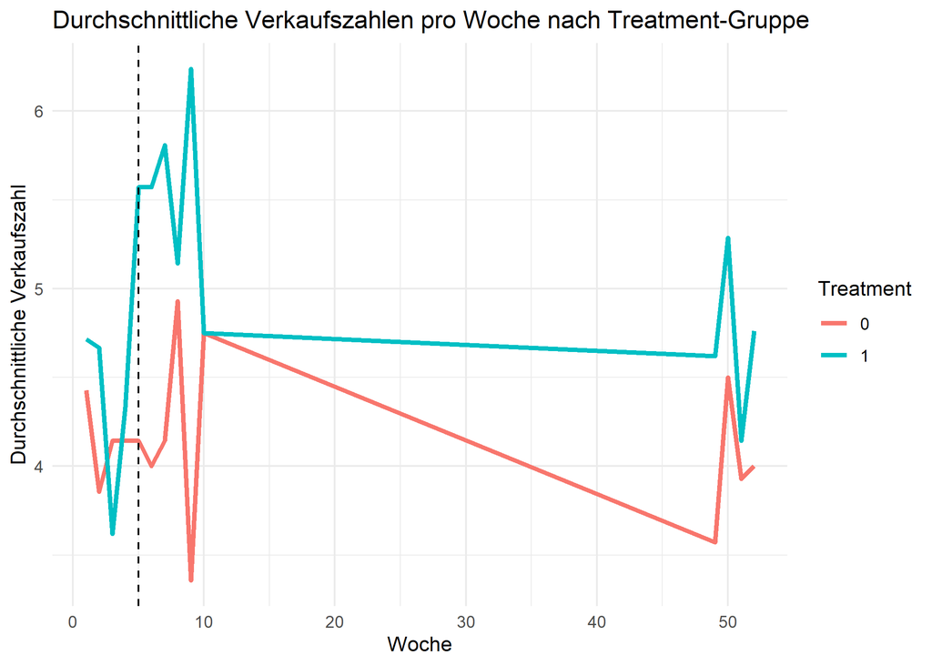

Falls nach dem 28. Januar die Verkaufszahlen der behandelten Gruppe (mit Kostentransparenz) deutlich stärker steigen als die der Kontrollgruppe, wäre dies ein visuelles Indiz dafür, dass die Infografik einen positiven Effekt auf die Verkaufszahlen hatte. Sollte hingegen kein Unterschied erkennbar sein oder beide Gruppen eine ähnliche Entwicklung zeigen, könnte dies darauf hindeuten, dass die Transparenzmaßnahme keinen wesentlichen Einfluss auf die Kaufentscheidung hatte.

## Eine weitere quantitative Analyse ist erforderlich, um den Effekt statistisch zu testen. Eine Difference-in-Differences-Regression würde nun ermitteln, ob der beobachtete Unterschied tatsächlich signifikant und auf die Transparenzmaßnahme zurückzuführen ist.

21. Erstellen Sie eine (mehrere) weitere passende Grafik(en), die die durchschnittlich verkauften Einheiten pro Tag in Treatment und Kontrolle vor und nach der Einführung der Kostentransparenz abbildet. Ergänzen Sie in ihrer Grafik die jeweiligen Standardfehler als Fehlerbalken. Beschreiben und interpretieren Sie ihre Grafik. Gehen Sie insbesondere auf die Unterschiede vor und nach der Einführung der Kostentransparenz ein.
- Inwiefern lassen sich daraus erste Hinweise auf einen möglichen Effekt des natürlichen Experiments erkennen?

*Hinweis:* Für die Erstellung der Grafik können Sie sich an Aufgabe 7 und 9 orientieren.

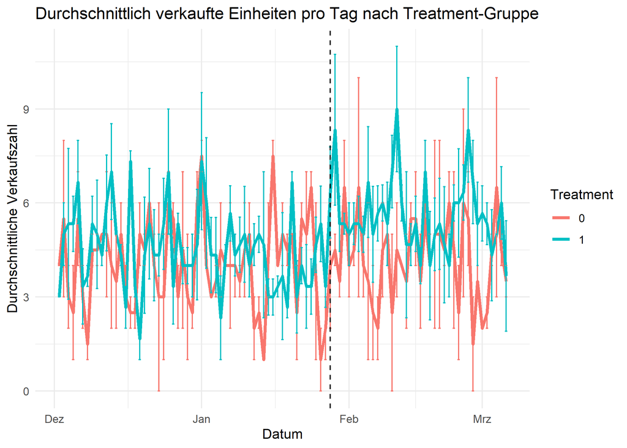

22. In der vorherigen Aufgabe haben Sie den Effekt von Kostentransparenz auf die Verkaufszahlen anhand eines deskriptiven Vergleichs untersucht. Dabei haben Sie die durchschnittlich täglich verkauften Einheiten je Treatment vor und nach der Einführung der Transparenzmaßnahme grafisch gegenübergestellt. In dieser Aufgabe sollen Sie diesen Effekt nun ökonometrisch genauer untersuchen, indem Sie den Difference-in-Differences Ansatz in einem Regressionsrahmen anwenden.

Untersuchen Sie den Effekt der Einführung von Kostentransparenz auf die Verkaufszahlen mithilfe einer Difference-in-Differences Regression. Verwenden Sie hierfür Beobachtungen an Werktagen, sowie am Wochenende (Montag bis Sonntag), mit positiven Verkaufszahlen.

Erstellen Sie insgesamt zwei Regressionsmodelle:

- Basismodell ohne Kontrollvariablen
- Modell mit Kontrolle für Wochentagseffekte

Stellen Sie die Ergebnisse anschaulich dar. Beschreiben und interpretieren Sie Ihre Ergebnisse. Gehen Sie insbesondere auf folgende Aspekte ein.

- Wie würden Sie die Größe des Effekts interpretieren, den Sie für `treated:post` erhalten haben?
- Welche Vorteile bringt es, log_units (logarithmierte Verkäufe) als abhängige Variable zu verwenden?
- Können Sie aus Ihrer Schätzung auf einen kausalen Effekt der Kostentransparenz schließen?
- Inwiefern hilft die Kontrolle für Wochentage dabei, Verzerrungen in der Schätzung zu vermeiden?
- Würden Sie auf Basis Ihrer Analyse eine Empfehlung zur Beibehaltung oder Ausweitung der Kostentransparenz geben?
- Worin könnten ihrer Ansicht nach Probleme liegen bei der Betrachtung eines natürlichen Experiments, die die Ergebnisse verzerren könnten?

*Hinweis 1:* Nutzen Sie für die Schätzung die `feols()`-Funktion aus dem fixest-Paket.

*Hinweis 2:* Nutzen Sie die logarithmierten täglichen Verkaufszahlen als abhängige Variable.

# Literatur

Mohan, B., Buell, R. W., & John, L. K. (2020). Lifting the veil: The benefits of cost transparency. Marketing Science, 39(6), 1105-1121. https://doi.org/10.1287/mksc.2019.1200

# Anhang

## Mediator

Im Rahmen von Mediationen ist der Mediator eine Variable, die den erklärenden Zusammenhang zwischen einer unabhängigen und einer abhängigen Variable vermittelt. Dabei wird untersucht, inwieweit der Einfluss der unabhängigen Variablen (z.B. Kostentransparenz) auf die abhängige Variable (z.B. Kaufabsicht) über einen vermittelnden Mechanismus - wie das Vertrauen der Kunden - erfolgt.

1. **Mediatoreffekt**: Der Mediatoren-Effekt, oft als ACME (Average Causal Mediation Effect) bezeichnet, beschreibt den indirekten Effekt, den die unabhängige Variable auf die abhängige Variable über den Mediator ausübt. Ist dieser Effekt signifikant, signalisiert dies, dass ein wesentlicher Teil des gesamten Einflusses über den vermittelnden Mechanismus läuft. Gleichzeitig kann ein nicht-signifikanter direkter Effekt (ADE - Average Direct Effect) darauf hindeuten, dass der Mediator den hauptsächlichen Erklärungsmechanismus darstellt.
2. **Funktion und Wirkung des Mediators**: Analog zum Konzept der signalgebenden Funktion bei Statussymbolen - deren Wert unter anderem von der Exklusivität und dem sozialen Kontext abhängt - fungiert der Mediator als vermittelnder Kanal, der erklärt, wie und warum der ursprüngliche Zusammenhang zwischen zwei Variablen zustande kommt. Der Mediator „überträgt“ quasi den Effekt der unabhängigen Variable auf die abhängige Variable. Dadurch kann in Modellen, in denen der direkte Zusammenhang zwischen der unabhängigen und der abhängigen Variable durch die Einbeziehung des Mediators verschwindet oder abgeschwächt wird, abgeleitet werden, dass der Mechanismus über den Mediator läuft. Dies ermöglicht ein tieferes Verständnis der zugrundeliegenden psychologischen Prozesse - etwa wie das Vertrauen der Kunden die Wirkung von Kostentransparenz auf deren Kaufabsicht vermittelt.

Zusammengefasst spielt der Mediator eine zentrale Rolle bei der Aufklärung der kausalen Mechanismen, indem er als vermittelnder Faktor zwischen Ursache und Wirkung identifiziert wird. Die signifikante Vermittlung über den Mediator zeigt, dass nicht allein das Vorhandensein von Kostentransparenz entscheidend ist, sondern auch, inwiefern diese Transparenz das Vertrauen stärkt - was wiederum maßgeblich die Kaufabsicht beeinflusst. So liefert die Mediationsanalyse wertvolle Einsichten, die über einfache bivariate Zusammenhänge hinausgehen und die Komplexität kausaler Mechanismen innerhalb von sozialen oder marktorientierten Prozessen sichtbar machen.

## Informationen zum Studiendesign des Experiments 1 und 2

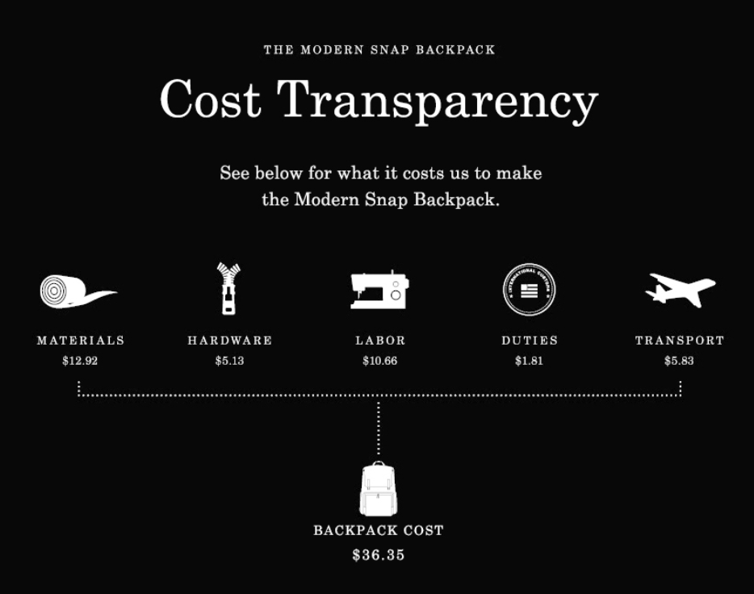

Abbildung 1: Kostentransparenz Infografik

[figure not shown]

Abbildung 2: Design der Schokoladenverpackung ohne und mit Kostentransparenz